# TP — Neural ODE de vieillissement : d'un véhicule à une flotte

## Objectif

On dispose d'un modèle électrique de batterie déjà calibré et de plusieurs profils d'usage synthétiques.

Dans ce TP, chaque profil de 7 jours est considéré comme un **véhicule distinct**.

L'objectif est d'introduire une méthodologie de modélisation du vieillissement par **Neural ODE**, d'abord sur un véhicule, puis à l'échelle d'une flotte.

On va :

1. construire un vieillissement synthétique volontairement simple ;
2. apprendre sa dynamique avec une Neural ODE ;
3. entraîner une même loi de vieillissement sur plusieurs véhicules ;
4. tester sa capacité à généraliser à de nouveaux véhicules ;
5. introduire une mémoire cachée liée à l'historique d'usage et montrer les limites d'un modèle sans mémoire.

## Hypothèses du TP

On suppose que le modèle électrique de la batterie a déjà été calibré.

En particulier, les paramètres des branches de relaxation sont considérés comme **connus et fixés** :

$$ R_i, \qquad \tau_i. $$

La courbe d'OCV ainsi que la dépendance de la résistance ohmique de référence en fonction du SOC et de la température sont également supposées connues :

$$ OCV(SOC), $$

$$ R_{0,\mathrm{base}}(SOC,T). $$

Le modèle électrique utilisé est :

$$ U(t) = OCV(SOC(t)) - R_0(SOC,T,t)\,I(t) - \sum_i U_{RC,i}(t). $$

Les branches de relaxation suivent :

$$ \frac{dU_{RC,i}}{dt} = -\frac{U_{RC,i}}{\tau_i} + \frac{R_i}{\tau_i}I. $$

On suppose la batterie **relaxée au début de chaque observation** :

$$ \boxed{ U_{RC,i}(0)=0 } $$

pour toutes les branches RC.

Le SOC évolue selon :

$$ \frac{dSOC}{dt} = -\frac{I(t)} {3600\,C_{\max}(t)}. $$

Le SOC initial est supposé connu :

$$ \boxed{ SOC(0)=SOC_0 } $$

et on ne considère pas dans ce TP les problématiques d'erreur d'initialisation, de biais de capteur ou de dérive progressive de l'estimation du SOC.

Autrement dit, on suppose que l'information de SOC utilisée par le modèle est suffisamment fiable pour se concentrer uniquement sur le problème de vieillissement.

## Paramètres étudiés

Dans ce TP, on ne cherche donc **pas à ré-identifier la dynamique électrique rapide**.

Les paramètres suivants restent fixés :

$$ R_i, \qquad \tau_i, \qquad OCV(SOC), \qquad R_{0,\mathrm{base}}(SOC,T). $$

On s'intéresse uniquement à l'évolution lente des grandeurs liées au vieillissement :

$$ \boxed{ C_{\max}(t) } $$

et

$$ \boxed{ R_0(t). } $$

On introduira deux variables de dommage :

$$ D_C(t) $$

pour la perte de capacité et

$$ D_R(t) $$

pour l'augmentation de résistance.

Elles seront reliées aux paramètres électriques par :

$$ C_{\max}(t) = C_{\max,0} \left( 1-D_C(t) \right), $$

et

$$ R_0(SOC,T,t) = R_{0,\mathrm{base}}(SOC,T) \left( 1+D_R(t) \right). $$

Le problème consiste donc à apprendre comment l'usage du véhicule fait évoluer :

$$ D_C \qquad\text{et}\qquad D_R. $$

## Vieillissement accéléré

Le vieillissement réel d'une batterie se produit normalement sur des périodes beaucoup plus longues que quelques jours.

Pour rendre les phénomènes directement observables pendant le TP, on va volontairement simuler un **vieillissement fortement accéléré sur une période de 7 jours**.

Les amplitudes de dégradation utilisées dans la suite ne cherchent donc pas à représenter le vieillissement réel d'une batterie en seulement une semaine.

Ce choix sert uniquement à illustrer la méthodologie :

$$ \boxed{ \text{usage} \rightarrow \text{dégradation} \rightarrow \text{évolution de } C_{\max} \text{ et } R_0 \rightarrow \text{tension mesurée} } $$

Le vieillissement synthétique sera décrit par une loi volontairement très simple dépendant du :

$$ SOC, \qquad T, \qquad I. $$

Cette simplicité est volontaire : dans un TP suivant, on repartira de la Neural ODE entraînée et on cherchera à **retrouver explicitement la loi de vieillissement apprise** à l'aide de méthodes de régression symbolique / SINDy.

# Installation des imports

```python
!pip -q install equinox optax
```

```
   ━━━━━━━━━━━━━━━━━━━━━━━━━━━━━━━━━━━━━━━━ 185.8/185.8 kB 5.4 MB/s eta 0:00:00
   ━━━━━━━━━━━━━━━━━━━━━━━━━━━━━━━━━━━━━━━━ 56.6/56.6 kB 5.1 MB/s eta 0:00:00
```

```python
import os
import json
import glob
import numpy as np
import matplotlib.pyplot as plt

import jax
import jax.numpy as jnp
import equinox as eqx # Pour la pogrammation orientée objet
import optax # Pour l'optimisation pour Jax

print("JAX :", jax.__version__)
print("Device :", jax.devices()[0])
```

```
JAX : 0.11.1
Device : cpu:0
```

```python
# ============================================================
# CHARTE GRAPHIQUE DU TP
# ============================================================

COLOR_U = "tab:blue"
COLOR_I = "tab:orange"
COLOR_T = "tab:red"
COLOR_SOC = "tab:green"

COLOR_C = "tab:purple"
COLOR_DAMAGE = "tab:brown"
COLOR_PRED = "tab:cyan"
COLOR_RESIDUAL = "tab:gray"

R0_CMAP = "viridis"

# Réglages scatter :
# avec des séries à ~1 Hz sur 7 jours, on utilise de très petits points.
SCATTER_SIZE = 2
SCATTER_ALPHA = 0.35
```

## Convention graphique

Les séries temporelles sont affichées sous forme de **nuages de points** plutôt que comme des courbes reliées.

La même charte est utilisée dans tout le TP :

- tension : bleu ;
- courant : orange ;
- température : rouge ;
- SOC : vert ;
- capacité : violet ;
- prédictions : cyan.

# Chargement des données

```python
#@title Chargement des données

NPZ_URL = (
    "https://github.com/lilredhood/"
    "FakeBatteryData/releases/download/"
    "tp2-v1/synthetic_battery_full.npz"
)

JSON_URL = (
    "https://github.com/lilredhood/"
    "FakeBatteryData/releases/download/"
    "tp2-v1/synthetic_battery_model.json"
)

!wget -q --show-progress "$NPZ_URL" -O synthetic_battery_full.npz
!wget -q --show-progress "$JSON_URL" -O synthetic_battery_model.json

data = np.load(
    "synthetic_battery_full.npz",
    allow_pickle=True,
)

with open(
    "synthetic_battery_model.json",
    "r",
    encoding="utf-8",
) as f:
    metadata = json.load(f)

print(
    "Nombre de points :",
    len(data["time_rel_s"]),
)

print(
    "Variables disponibles :",
    data.files,
)
```

```
synthetic_battery_f 100%[===================>] 165.82M  50.3MB/s    in 3.3s
synthetic_battery_m 100%[===================>]   2.00K  --.-KB/s    in 0s
Nombre de points : 1927562
Variables disponibles : ['time', 'time_rel_s', 'time_rel_h', 'dt', 'is_gap', 'I_raw', 'I_command', 'I', 'T', 'U', 'U_clean', 'SOC', 'OCV', 'R0', 'U_R0', 'U_RC', 'U_relax', 'Q_cum_Ah', 'C_MAX', 'SOC0', 'U0', 'U0_clean', 'U_NOM_SYN', 'OCV_coefficients', 'R0_MIN', 'A_SOC', 'A_TEMP', 'N_RC', 'TAU0', 'TA…
```

```python
# Séries principales
time_rel_s = np.asarray(data["time_rel_s"])
dt_all = np.asarray(data["dt"])
is_gap_all = np.asarray(data["is_gap"])

I_all = np.asarray(data["I"])
T_all = np.asarray(data["T"])
SOC_original_all = np.asarray(data["SOC"])
U_original_all = np.asarray(data["U"])

U_RC_all = np.asarray(data["U_RC"])

C0 = float(data["C_MAX"])
coef_ocv = np.asarray(data["OCV_coefficients"])

R0_MIN = float(data["R0_MIN"])
A_SOC = float(data["A_SOC"])
A_TEMP = float(data["A_TEMP"])

TAU = np.asarray(data["TAU"])
R_RC = np.asarray(data["R_RC"])

print("C0 =", C0, "Ah")
print("TAU =", TAU)
print("R_RC =", R_RC)
```

```
C0 = 250.0 Ah
TAU = [   5.   50.  500. 5000.]
R_RC = [0.015 0.02  0.025 0.03 ]
```

```python
def OCV_np(soc):
    soc = np.clip(np.asarray(soc), 0.0, 1.0)
    return np.polyval(coef_ocv, soc)

def softplus_np(x):
    return np.logaddexp(0.0, x)

def R0_base_np(soc, T):
    soc = np.asarray(soc)
    T = np.asarray(T)

    soc_effect = A_SOC * (soc - 0.5)**2

    temp_effect = (
        A_TEMP
        * softplus_np((25.0 - T) / 5.0)
        / softplus_np((25.0 - 14.0) / 5.0)
    )

    return R0_MIN + soc_effect + temp_effect

print("OCV(0.5) =", OCV_np(0.5), "V")
print("R0(0.5,25°C) =", R0_base_np(0.5, 25.0), "Ohm")
```

```
OCV(0.5) = 201.50645388970486 V
R0(0.5,25°C) = 0.8451055613444919 Ohm
```

# Un seul véhicule (A) : 7 jours d'usage 'accéléré"

On commence par un seul véhicule.

Le **Véhicule A** est observé pendant 7 jours à la résolution d'origine, soit environ 1 Hz.

```python
OBS_DURATION_S = 7 * 24 * 3600

mask_vehicle_A = time_rel_s <= OBS_DURATION_S
idx = np.where(mask_vehicle_A)[0]

t = time_rel_s[idx]
I = I_all[idx]
T = T_all[idx]
SOC_original = SOC_original_all[idx]
U_original = U_original_all[idx]

# Les états RC sont supposés connus grâce au modèle électrique pré-calibré.
U_RC = U_RC_all[idx]

dt = np.diff(t, prepend=t[0])
dt[0] = 0.0

# Les grands trous ne sont pas intégrés.
DT_MAX = 60.0
active = dt <= DT_MAX
dt_eff = np.where(active, dt, 0.0)

print("Véhicule A")
print("Nombre de points :", len(t))
print("Durée :", (t[-1] - t[0]) / 86400, "jours")
print("SOC :", SOC_original.min(), "->", SOC_original.max())
print("T :", T.min(), "->", T.max(), "°C")
print("I :", I.min(), "->", I.max(), "A")
```

```
Véhicule A
Nombre de points : 198470
Durée : 7.0 jours
SOC : 0.38003163888855646 -> 1.0
T : 20.0 -> 46.0 °C
I : -300.0 -> 200.0 A
```

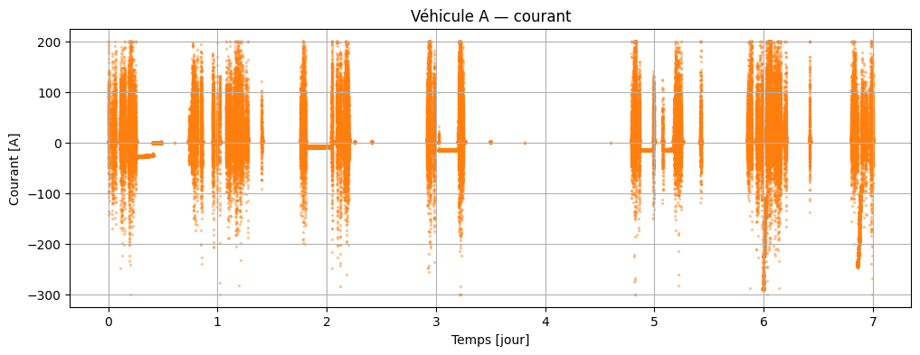

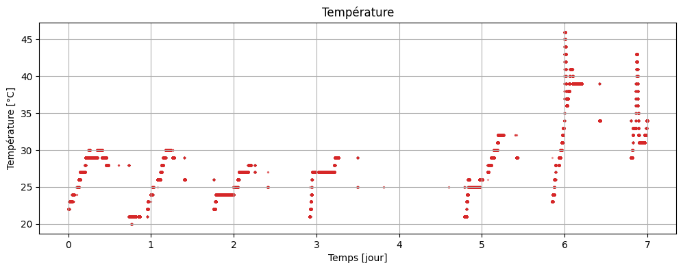

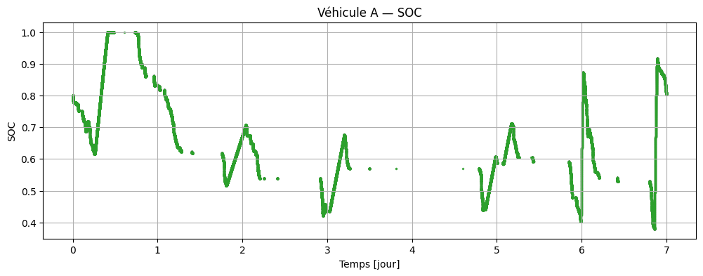

```python
fig = plt.figure(figsize=(12, 4))
plt.scatter(t / 86400, I, s=SCATTER_SIZE, alpha=SCATTER_ALPHA, color=COLOR_I, rasterized=True)
plt.xlabel("Temps [jour]")
plt.ylabel("Courant [A]")
plt.title("Véhicule A — courant")
plt.grid(True)
plt.show()

fig = plt.figure(figsize=(12, 4))
plt.scatter(t / 86400, T, s=SCATTER_SIZE, alpha=SCATTER_ALPHA, color=COLOR_T, rasterized=True)
plt.xlabel("Temps [jour]")
plt.ylabel("Température [°C]")
plt.title("Température")
plt.grid(True)
plt.show()

fig = plt.figure(figsize=(12, 4))
plt.scatter(t / 86400, SOC_original, s=SCATTER_SIZE, alpha=SCATTER_ALPHA, color=COLOR_SOC, rasterized=True)
plt.xlabel("Temps [jour]")
plt.ylabel("SOC")
plt.title("Véhicule A — SOC")
plt.grid(True)
plt.show()
```

## Création d'un vieillissement synthétique

On crée maintenant une **nouvelle batterie fictive**.

### Variables de dommage

On définit deux variables monotones :

$$ D_C(t)\geq0 $$

pour la perte de capacité, et

$$ D_R(t)\geq0 $$

pour l'augmentation de résistance.

On pose :

$$ \boxed{ C_{\max}(t)=C_0(1-D_C(t)) } $$

et

$$ \boxed{ R_0^{aged}(SOC,T,t) = R_0^{base}(SOC,T)(1+D_R(t)) } $$

### Vieillissement calendaire connu

On choisit volontairement une loi très simple :

$$ D_{C,cal}(t) = 0.005\sqrt{\frac{t}{7\,jours}} $$

$$ D_{R,cal}(t) = 0.01\sqrt{\frac{t}{7\,jours}}. $$

Sur 7 jours cela représente :

- **0.5 %** de perte de capacité ;
- **1 %** d'augmentation de résistance.

C'est volontairement énorme pour 7 jours, c'est pour la simplicité

```python
t_norm_obs = np.clip(
    t / OBS_DURATION_S,
    0.0,
    1.0,
)

D_C_cal_true = (
    0.005
    * np.sqrt(t_norm_obs)
)

D_R_cal_true = (
    0.010
    * np.sqrt(t_norm_obs)
)
```

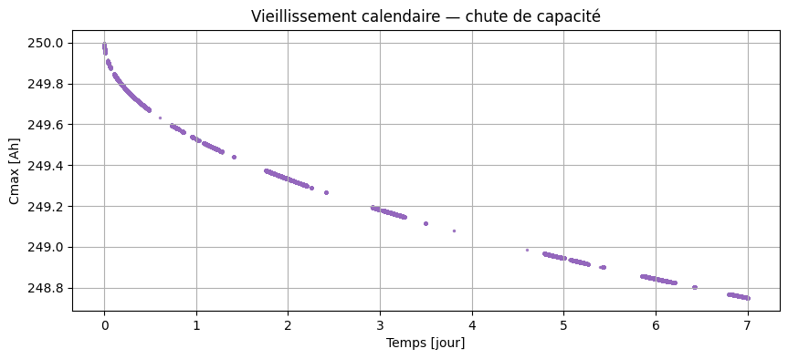

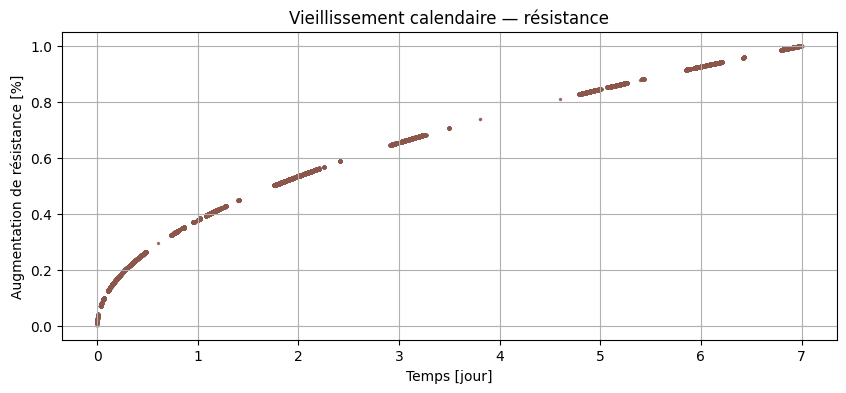

```python
# ============================================================
# VISUALISATION DU VIEILLISSEMENT CALENDAIRE
# ============================================================

# Capacité restante sous l'effet du vieillissement calendaire
C_cal_true = (
    C0
    * (1.0 - D_C_cal_true)
)

fig = plt.figure(figsize=(10, 4))

plt.scatter(
    t / 86400,
    C_cal_true,
    s=SCATTER_SIZE,
    alpha=SCATTER_ALPHA,
    color=COLOR_C,
    rasterized=True,
)

plt.xlabel("Temps [jour]")
plt.ylabel("Cmax [Ah]")
plt.title("Vieillissement calendaire — chute de capacité")
plt.grid(True)

plt.show()


fig = plt.figure(figsize=(10, 4))

plt.scatter(
    t / 86400,
    100 * D_R_cal_true,
    s=SCATTER_SIZE,
    alpha=SCATTER_ALPHA,
    color=COLOR_DAMAGE,
    rasterized=True,
)

plt.xlabel("Temps [jour]")
plt.ylabel("Augmentation de résistance [%]")
plt.title("Vieillissement calendaire — résistance")
plt.grid(True)

plt.show()
```

### Loi de cyclage cachée — volontairement minimale

Le but est de choisir une loi **très simple**, afin de pouvoir essayer de la retrouver explicitement dans le TP suivant avec SINDy / régression symbolique.

On utilise trois entrées normalisées :

$$ SOC, \qquad \widetilde T=\frac{T-25}{20}, \qquad \widetilde I=\frac{|I|}{200}. $$

La vraie loi synthétique de perte de capacité est :

$$ \boxed{ \frac{dD_{C,\mathrm{cyc}}}{dQ} = k_C \left( 1 + SOC + 0.5\,\widetilde T + 0.5\,\widetilde I \right) } $$

et la vraie loi synthétique de croissance de résistance est :

$$ \boxed{ \frac{dD_{R,\mathrm{cyc}}}{dQ} = k_R \left( 1 + 0.5\,SOC + 0.5\,\widetilde T + \widetilde I \right). } $$

avec :

$$ dQ = \frac{|I|}{3600}\,dt. $$

Le courant intervient donc de **deux façons** :

- via le débit de charge $dQ$ ;
- via le niveau de sollicitation $\widetilde I$ dans la loi.

La structure cachée est volontairement affine :

$$ \boxed{ a_0+a_1SOC+a_2\widetilde T+a_3\widetilde I } $$

```python
dQ = (
    np.abs(I)
    * dt_eff
    / 3600.0
)

T_scaled = (
    T - 25.0
) / 20.0

I_scaled = (
    np.abs(I)
    / 200.0
)

# ------------------------------------------------------------
# VRAIES LOIS AFFINES TRÈS SIMPLES
# ------------------------------------------------------------

stress_C = (
    1.0
    + 1.0 * SOC_original
    + 0.5 * T_scaled
    + 0.5 * I_scaled
)

stress_R = (
    1.0
    + 0.5 * SOC_original
    + 0.5 * T_scaled
    + 1.0 * I_scaled
)

# Cibles pédagogiques sur le Véhicule A
TARGET_D_C_CYC = 0.035
TARGET_D_R_CYC = 0.090

kC_true = (
    TARGET_D_C_CYC
    / np.sum(
        stress_C * dQ
    )
)

kR_true = (
    TARGET_D_R_CYC
    / np.sum(
        stress_R * dQ
    )
)

TRUE_COEFF_C = {
    "constant": 1.0,
    "SOC": 1.0,
    "T_scaled": 0.5,
    "I_scaled": 0.5,
}

TRUE_COEFF_R = {
    "constant": 1.0,
    "SOC": 0.5,
    "T_scaled": 0.5,
    "I_scaled": 1.0,
}

print("kC_true =", kC_true)
print("kR_true =", kR_true)
print("Loi C :", TRUE_COEFF_C)
print("Loi R :", TRUE_COEFF_R)
```

```
kC_true = 1.117347578733519e-05
kR_true = 3.0266692721274014e-05
Loi C : {'constant': 1.0, 'SOC': 1.0, 'T_scaled': 0.5, 'I_scaled': 0.5}
Loi R : {'constant': 1.0, 'SOC': 0.5, 'T_scaled': 0.5, 'I_scaled': 1.0}
```

```python
# Intégration de la loi cachée
D_C_cyc_true = np.cumsum(kC_true * stress_C * dQ)
D_R_cyc_true = np.cumsum(kR_true * stress_R * dQ)

D_C_true = D_C_cal_true + D_C_cyc_true
D_R_true = D_R_cal_true + D_R_cyc_true

C_true = C0 * (1.0 - D_C_true)

print("D_C final =", D_C_true[-1])
print("D_R final =", D_R_true[-1])
print("Cmax initial =", C0, "Ah")
print("Cmax final   =", C_true[-1], "Ah")
```

```
D_C final = 0.03999999999999934
D_R final = 0.09999999999999952
Cmax initial = 250.0 Ah
Cmax final   = 240.00000000000017 Ah
```

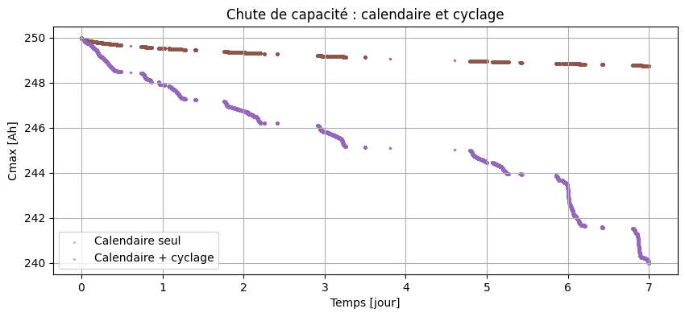

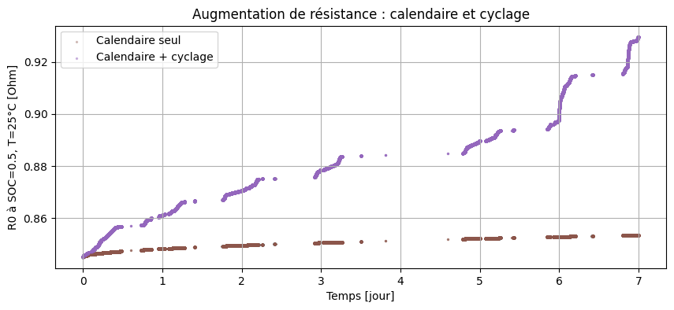

```python
# ============================================================
# VIEILLISSEMENT TOTAL = CALENDAIRE + CYCLAGE
# ============================================================

D_C_true = (
    D_C_cal_true
    + D_C_cyc_true
)

D_R_true = (
    D_R_cal_true
    + D_R_cyc_true
)

# ------------------------------------------------------------
# CAPACITÉ
# ------------------------------------------------------------

C_cal_true = (
    C0
    * (1.0 - D_C_cal_true)
)

C_total_true = (
    C0
    * (1.0 - D_C_true)
)

fig = plt.figure(figsize=(10, 4))

plt.scatter(
    t / 86400,
    C_cal_true,
    s=SCATTER_SIZE,
    alpha=0.30,
    color=COLOR_DAMAGE,
    label="Calendaire seul",
    rasterized=True,
)

plt.scatter(
    t / 86400,
    C_total_true,
    s=SCATTER_SIZE,
    alpha=0.40,
    color=COLOR_C,
    label="Calendaire + cyclage",
    rasterized=True,
)

plt.xlabel("Temps [jour]")
plt.ylabel("Cmax [Ah]")
plt.title(
    "Chute de capacité : "
    "calendaire et cyclage"
)

plt.legend()
plt.grid(True)
plt.show()


# ------------------------------------------------------------
# RÉSISTANCE
# ------------------------------------------------------------

R0_ref = R0_base_np(
    0.5,
    25.0,
)

R0_cal_true = (
    R0_ref
    * (1.0 + D_R_cal_true)
)

R0_total_true = (
    R0_ref
    * (1.0 + D_R_true)
)

fig = plt.figure(figsize=(10, 4))

plt.scatter(
    t / 86400,
    R0_cal_true,
    s=SCATTER_SIZE,
    alpha=0.30,
    color=COLOR_DAMAGE,
    label="Calendaire seul",
    rasterized=True,
)

plt.scatter(
    t / 86400,
    R0_total_true,
    s=SCATTER_SIZE,
    alpha=0.40,
    color=COLOR_C,
    label="Calendaire + cyclage",
    rasterized=True,
)

plt.xlabel("Temps [jour]")
plt.ylabel(
    "R0 à SOC=0.5, T=25°C [Ohm]"
)

plt.title(
    "Augmentation de résistance : "
    "calendaire et cyclage"
)

plt.legend()
plt.grid(True)
plt.show()
```

## Re-simuler le SOC avec la capacité vieillissante

Point important :

si on fournit le SOC exact à chaque instant au modèle, alors la capacité devient très difficile à identifier.

Pour que $C_{\max}$ soit observable, nous ne donnons au modèle que :

$$ SOC(0) $$

puis il doit propager :

$$ \boxed{ SOC_{k+1} = SOC_k - \frac{I_k\Delta t_k} {3600\,C_{\max,k}} } $$

La dérive du SOC contient donc de l'information sur la capacité.

```python
SOC_true = np.zeros_like(t, dtype=float)
SOC_true[0] = SOC_original[0]

for k in range(len(t) - 1):
    Ck = C_true[k]

    soc_next = (
        SOC_true[k]
        - I[k] * dt_eff[k + 1] / (3600.0 * Ck)
    )

    SOC_true[k + 1] = np.clip(soc_next, 0.0, 1.0)

print("SOC aged :", SOC_true.min(), "->", SOC_true.max())
```

```
SOC aged : 0.3686841532463226 -> 1.0
```

## Génération de la tension vieillie

On conserve les relaxations électriques du modèle initial comme partie **connue / pré-calibrée** :

$$ \sum_i U_{RC,i}(t). $$

La nouvelle tension vaut :

$$ U^{aged} = OCV(SOC^{aged}) - R_0^{base}(SOC^{aged},T) (1+D_R) I - \sum_i U_{RC,i}. $$

On ajoute ensuite un petit bruit de mesure.

```python
R0_base_true = R0_base_np(SOC_true, T)
R0_aged_true = R0_base_true * (1.0 + D_R_true)

U_clean_aged = (
    OCV_np(SOC_true)
    - R0_aged_true * I
    - np.sum(U_RC, axis=1)
)

rng = np.random.default_rng(123)
NOISE_STD = 0.05

U_meas = U_clean_aged + rng.normal(
    0.0,
    NOISE_STD,
    size=len(U_clean_aged)
)
```

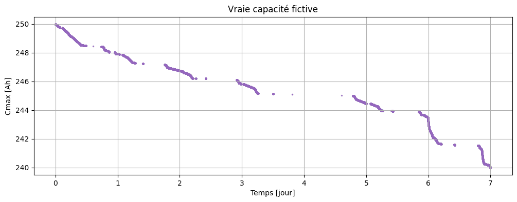

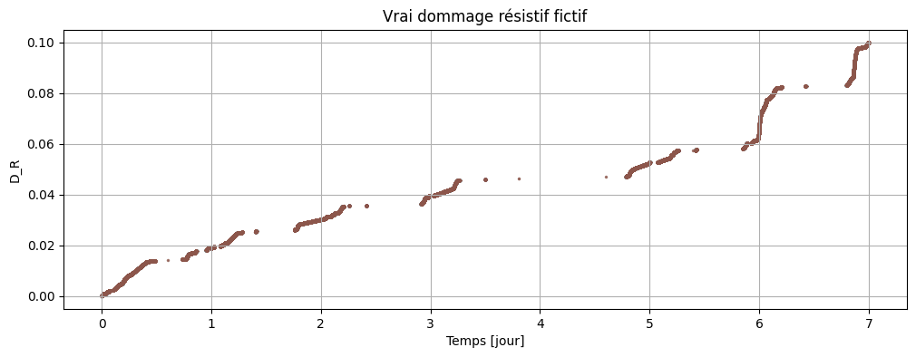

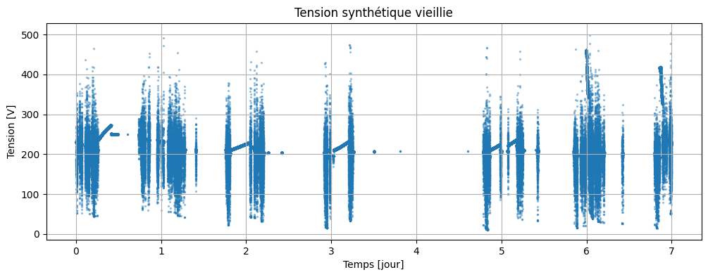

```python
fig = plt.figure(figsize=(12, 4))
plt.scatter(t / 86400, C_true, s=SCATTER_SIZE, alpha=SCATTER_ALPHA, color=COLOR_C, rasterized=True)
plt.xlabel("Temps [jour]")
plt.ylabel("Cmax [Ah]")
plt.title("Vraie capacité fictive")
plt.grid(True)
plt.show()

fig = plt.figure(figsize=(12, 4))
plt.scatter(t / 86400, D_R_true, s=SCATTER_SIZE, alpha=SCATTER_ALPHA, color=COLOR_DAMAGE, rasterized=True)
plt.xlabel("Temps [jour]")
plt.ylabel("D_R")
plt.title("Vrai dommage résistif fictif")
plt.grid(True)
plt.show()

fig = plt.figure(figsize=(12, 4))
plt.scatter(t / 86400, U_meas, s=SCATTER_SIZE, alpha=SCATTER_ALPHA, color=COLOR_U, rasterized=True)
plt.xlabel("Temps [jour]")
plt.ylabel("Tension [V]")
plt.title("Tension synthétique vieillie")
plt.grid(True)
plt.show()
```

## Problème inverse

Nous oublions maintenant les lois utilisées pour générer $D_{C,cyc}$ et $D_{R,cyc}$.

La seule information que nous conservons est :

- le courant $I(t)$ ;
- la température $T(t)$ ;
- le SOC initial ;
- la tension mesurée $U(t)$ ;
- l'ECM pré-calibré ;
- la loi calendaire connue.

On cherche :

$$ \boxed{ \frac{dD_{C,cyc}}{dQ} = f_{\theta,C}(SOC,T,|I|) } $$

$$ \boxed{ \frac{dD_{R,cyc}}{dQ} = f_{\theta,R}(SOC,T,|I|) } $$

avec un réseau de neurones.

Pour imposer la monotonie :

$$ f_{\theta,C}\geq0, \qquad f_{\theta,R}\geq0 $$

grâce à une `softplus`.

```python
# Passage en JAX
t_j = jnp.asarray(t)
dt_j = jnp.asarray(dt_eff)
I_j = jnp.asarray(I)
T_j = jnp.asarray(T)
U_RC_j = jnp.asarray(U_RC)
U_meas_j = jnp.asarray(U_meas)

coef_ocv_j = jnp.asarray(coef_ocv)

C0_j = jnp.asarray(C0)
```

```python
def OCV_jax(soc):
    soc = jnp.clip(soc, 0.0, 1.0)
    return jnp.polyval(coef_ocv_j, soc)

def R0_base_jax(soc, temp):
    soc_effect = A_SOC * (soc - 0.5)**2

    temp_effect = (
        A_TEMP
        * jax.nn.softplus((25.0 - temp) / 5.0)
        / jax.nn.softplus((25.0 - 14.0) / 5.0)
    )

    return R0_MIN + soc_effect + temp_effect

def calendar_damage(t_seconds):
    x = jnp.clip(t_seconds / OBS_DURATION_S, 0.0, 1.0)

    D_C_cal = 0.005 * jnp.sqrt(x + 1e-12)
    D_R_cal = 0.010 * jnp.sqrt(x + 1e-12)

    return D_C_cal, D_R_cal
```

## Neural ODE

La Neural ODE reçoit maintenant :

$$ x= \begin{bmatrix} SOC\\ \widetilde T\\ \widetilde I \end{bmatrix} $$

avec :

$$ \widetilde T=\frac{T-25}{20}, \qquad \widetilde I=\frac{|I|}{200}. $$

Elle retourne les deux vitesses de dommage :

$$ \frac{dD_C}{dQ}, \qquad \frac{dD_R}{dQ}. $$

On utilise volontairement un petit MLP :

$$ 3\rightarrow16\rightarrow16\rightarrow2. $$

## Solveur numérique : Euler explicite

Ici, on n'utilise **pas** un solveur adaptatif du type RK4 / Tsit5 / Diffrax.

La Neural ODE est intégrée directement sur la grille temporelle des données avec un **Euler explicite**.

À chaque mesure $k$ :

$$ \Delta Q_k = \frac{|I_k|\Delta t_k}{3600}. $$

Puis :

$$ \boxed{ D_{C,k+1} = D_{C,k} + f_{\theta,C} (SOC_k,T_k,I_k) \,\Delta Q_k } $$

et :

$$ \boxed{ D_{R,k+1} = D_{R,k} + f_{\theta,R} (SOC_k,T_k,I_k) \,\Delta Q_k. } $$

Le SOC est lui aussi propagé par Euler explicite :

$$ \boxed{ SOC_{k+1} = SOC_k - \frac{I_k\Delta t_k} {3600\,C_{\max,k}}. } $$

Dans le code, `jax.lax.scan` n'est donc **pas le solveur** : il sert à appliquer efficacement et de façon différentiable ce pas d'Euler sur toute la longue série temporelle à environ 1 Hz.

Les paramètres électriques des branches RC restent fixés pendant tout le TP.

```python
class AgeingNN(eqx.Module):
    mlp: eqx.nn.MLP

    def __init__(self, key):
        self.mlp = eqx.nn.MLP(
            in_size=3,
            out_size=2,
            width_size=16,
            depth=2,
            activation=jax.nn.tanh,
            key=key,
        )

    def __call__(
        self,
        soc,
        temp,
        current,
    ):
        x = jnp.array([
            soc,
            (temp - 25.0) / 20.0,
            jnp.abs(current) / 200.0,
        ])

        raw = self.mlp(x)

        # D_C et D_R doivent être monotones
        return jax.nn.softplus(raw)
```

```python
RATE_SCALE_C = 2.0e-5
RATE_SCALE_R = 5.0e-5

def simulate(model):
    # état = SOC, D_C_cyc, D_R_cyc
    initial_state = jnp.array([
        SOC_true[0],
        0.0,
        0.0,
    ])

    def step(carry, inputs):
        soc, D_C_cyc, D_R_cyc = carry

        tk, dtk, Ik, Tk, urc_k = inputs

        D_C_cal, D_R_cal = calendar_damage(tk)

        D_C_total = D_C_cal + D_C_cyc
        D_R_total = D_R_cal + D_R_cyc

        # sécurité numérique
        D_C_total = jnp.clip(D_C_total, 0.0, 0.40)
        D_R_total = jnp.clip(D_R_total, 0.0, 1.00)

        Cmax = C0_j * (1.0 - D_C_total)

        R0 = (
            R0_base_jax(soc, Tk)
            * (1.0 + D_R_total)
        )

        U_pred = (
            OCV_jax(soc)
            - R0 * Ik
            - jnp.sum(urc_k)
        )

        # Neural ODE en Q
        rates = model(soc, Tk, Ik)

        dQk = jnp.abs(Ik) * dtk / 3600.0

        D_C_cyc_next = (
            D_C_cyc
            + RATE_SCALE_C * rates[0] * dQk
        )

        D_R_cyc_next = (
            D_R_cyc
            + RATE_SCALE_R * rates[1] * dQk
        )

        soc_next = (
            soc
            - Ik * dtk / (3600.0 * Cmax)
        )

        soc_next = jnp.clip(soc_next, 0.0, 1.0)

        new_carry = jnp.array([
            soc_next,
            D_C_cyc_next,
            D_R_cyc_next,
        ])

        output = jnp.array([
            U_pred,
            soc,
            Cmax,
            R0,
            D_C_total,
            D_R_total,
        ])

        return new_carry, output

    inputs = (
        t_j,
        dt_j,
        I_j,
        T_j,
        U_RC_j,
    )

    _, outputs = jax.lax.scan(
        step,
        initial_state,
        inputs,
    )

    return outputs
```

Avant l'entraînement, les poids du réseau sont initialisés aléatoirement.

$$ f_\theta(SOC,T,I) $$

L'optimisation va ensuite modifier les paramètres $\theta$ afin que, après intégration de cette dynamique de vieillissement, la tension simulée reproduise la tension observée.

```python
# ============================================================
# VIEILLISSEMENT PRÉDIT AVANT ENTRAÎNEMENT
# ============================================================

out_init = np.asarray(
    simulate(model)
)

C_init = out_init[:, 2]
DR_init = out_init[:, 5]

# Résistance ramenée à des conditions fixes
# pour ne visualiser que le vieillissement
R0_ref_BOL = float(
    R0_base_np(
        0.5,
        25.0,
    )
)

R0_init = (
    R0_ref_BOL
    * (1.0 + DR_init)
)
```

[figure not shown]

```python
fig = plt.figure(
    figsize=(10, 4)
)

plt.scatter(
    t / 86400,
    C_init,
    s=SCATTER_SIZE,
    alpha=SCATTER_ALPHA,
    color=COLOR_C,
    rasterized=True,
)

plt.xlabel("Temps [jour]")
plt.ylabel("Cmax [Ah]")

plt.title(
    "Neural ODE avant entraînement — "
    "évolution de la capacité"
)

plt.grid(True)
plt.show()
```

[figure not shown]

```python
fig = plt.figure(
    figsize=(10, 4)
)

plt.scatter(
    t / 86400,
    R0_init,
    s=SCATTER_SIZE,
    alpha=SCATTER_ALPHA,
    color=COLOR_DAMAGE,
    rasterized=True,
)

plt.xlabel("Temps [jour]")

plt.ylabel(
    "R0 à SOC=0.5, T=25°C [Ohm]"
)

plt.title(
    "Neural ODE avant entraînement — "
    "évolution de la résistance"
)

plt.grid(True)
plt.show()
```

## Fonction de coût

On utilise la tension sur toute la trajectoire :

$$ \mathcal L_U = MSE(U_{pred},U_{mes}). $$

L'objectif du TP reste l'apprentissage de la **dynamique de vieillissement**.

```python
def loss_fn(model):
    out = simulate(model)

    U_pred = out[:, 0]

    # --------------------------------------------------------
    # LOSS UNIQUEMENT SUR LA TENSION
    # --------------------------------------------------------

    loss_U = jnp.mean(
        (
            (
                U_pred
                - U_meas_j
            )
            / 0.5
        )**2
    )

    return loss_U, loss_U
```

## Entraînement

On entraîne les paramètres du réseau avec Adam.

Pour un TP, 300 à 600 époques suffisent normalement pour voir la dynamique apparaître.

```python
key = jax.random.PRNGKey(0)
model = AgeingNN(key)

optimizer = optax.chain(
    optax.clip_by_global_norm(1.0),
    optax.adam(1e-3),
)

opt_state = optimizer.init(
    eqx.filter(model, eqx.is_array)
)

@eqx.filter_jit
def train_step(model, opt_state):
    (loss, aux), grads = eqx.filter_value_and_grad(
        loss_fn,
        has_aux=True,
    )(model)

    updates, opt_state = optimizer.update(
        grads,
        opt_state,
        eqx.filter(model, eqx.is_array),
    )

    model = eqx.apply_updates(
        model,
        updates,
    )

    return model, opt_state, loss, aux
```

```python
N_EPOCHS = 300

history = []

for epoch in range(N_EPOCHS):
    model, opt_state, loss, aux = train_step(
        model,
        opt_state,
    )

    history.append(float(loss))

    if (
        epoch % 10 == 0
        or epoch == N_EPOCHS - 1
    ):
        loss_U = aux

        print(
            f"Epoch {epoch:4d} | "
            f"Loss={float(loss):.5f} | "
        )
```

```
Epoch    0 | Loss=0.02136 |
Epoch   10 | Loss=0.01957 |
Epoch   20 | Loss=0.01800 |
Epoch   30 | Loss=0.01664 |
Epoch   40 | Loss=0.01544 |
Epoch   50 | Loss=0.01446 |
Epoch   60 | Loss=0.01368 |
Epoch   70 | Loss=0.01307 |
Epoch   80 | Loss=0.01260 |
Epoch   90 | Loss=0.01227 |
Epoch  100 | Loss=0.01203 |
```

[output not shown]

[figure not shown]

```python
fig = plt.figure(figsize=(8, 4))
plt.semilogy(history)
plt.xlabel("Epoch")
plt.ylabel("Loss")
plt.title("Convergence")
plt.grid(True)
plt.show()
```

## Résultats

On compare maintenant :

- tension prédite / vraie ;
- SOC prédit / vrai ;
- capacité prédite / vraie ;
- dommage résistif prédit / vrai.

```python
out = np.asarray(simulate(model))

U_pred = out[:, 0]
SOC_pred = out[:, 1]
C_pred = out[:, 2]
R0_pred = out[:, 3]
DC_pred = out[:, 4]
DR_pred = out[:, 5]
```

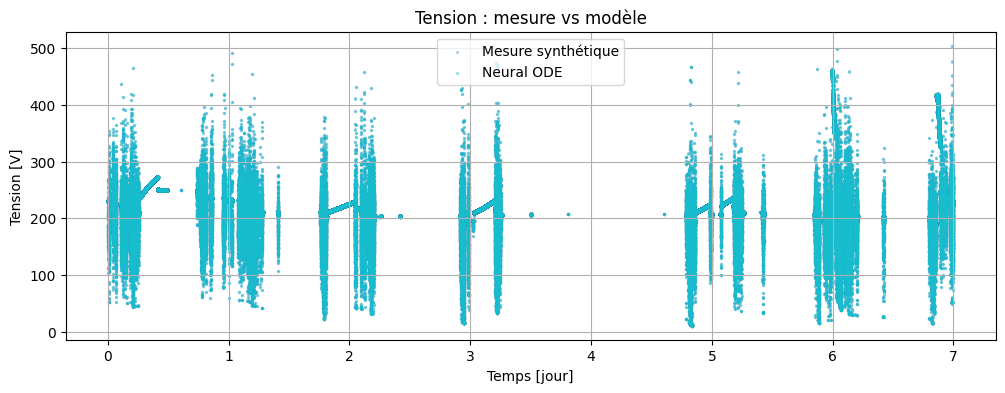

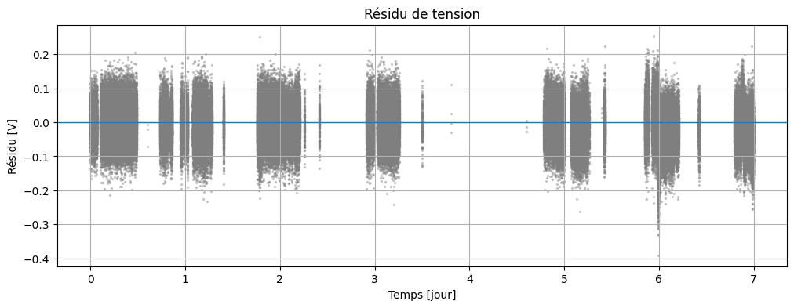

```
RMSE tension = 0.05446247889453308 V
```

```python
fig = plt.figure(figsize=(12, 4))
plt.scatter(t / 86400, U_meas, s=SCATTER_SIZE, alpha=0.25, color=COLOR_U, label="Mesure synthétique", rasterized=True)
plt.scatter(t / 86400, U_pred, s=SCATTER_SIZE, alpha=0.35, color=COLOR_PRED, label="Neural ODE", rasterized=True)
plt.xlabel("Temps [jour]")
plt.ylabel("Tension [V]")
plt.title("Tension : mesure vs modèle")
plt.legend()
plt.grid(True)
plt.show()

residual = U_meas - U_pred

fig = plt.figure(figsize=(12, 4))
plt.scatter(t / 86400, residual, s=SCATTER_SIZE, alpha=SCATTER_ALPHA, color=COLOR_RESIDUAL, rasterized=True)
plt.axhline(0.0, lw=1)
plt.xlabel("Temps [jour]")
plt.ylabel("Résidu [V]")
plt.title("Résidu de tension")
plt.grid(True)
plt.show()

print("RMSE tension =", np.sqrt(np.mean(residual**2)), "V")
```

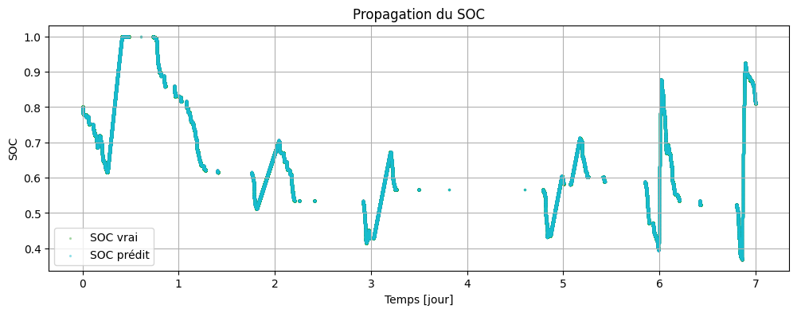

```python
fig = plt.figure(figsize=(12, 4))
plt.scatter(t / 86400, SOC_true, s=SCATTER_SIZE, alpha=0.30, color=COLOR_SOC, label="SOC vrai", rasterized=True)
plt.scatter(t / 86400, SOC_pred, s=SCATTER_SIZE, alpha=0.35, color=COLOR_PRED, label="SOC prédit", rasterized=True)
plt.xlabel("Temps [jour]")
plt.ylabel("SOC")
plt.title("Propagation du SOC")
plt.legend()
plt.grid(True)
plt.show()
```

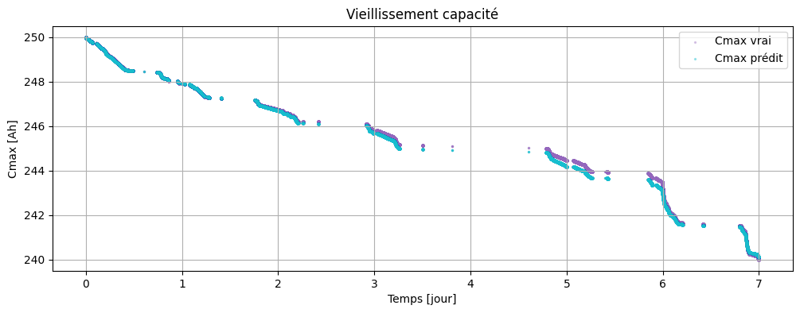

```
Cmax vrai final   : 240.00000000000017 Ah
Cmax prédit final : 240.08992 Ah
```

```python
fig = plt.figure(figsize=(12, 4))
plt.scatter(t / 86400, C_true, s=SCATTER_SIZE, alpha=0.30, color=COLOR_C, label="Cmax vrai", rasterized=True)
plt.scatter(t / 86400, C_pred, s=SCATTER_SIZE, alpha=0.35, color=COLOR_PRED, label="Cmax prédit", rasterized=True)
plt.xlabel("Temps [jour]")
plt.ylabel("Cmax [Ah]")
plt.title("Vieillissement capacité")
plt.legend()
plt.grid(True)
plt.show()

print("Cmax vrai final   :", C_true[-1], "Ah")
print("Cmax prédit final :", C_pred[-1], "Ah")
```

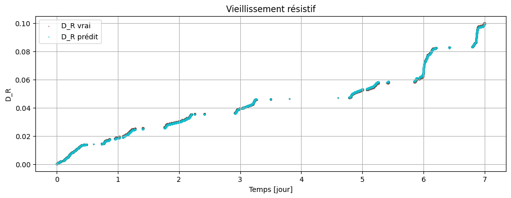

```
D_R vrai final   : 0.09999999999999952
D_R prédit final : 0.09915958
```

```python
fig = plt.figure(figsize=(12, 4))
plt.scatter(t / 86400, D_R_true, s=SCATTER_SIZE, alpha=0.30, color=COLOR_DAMAGE, label="D_R vrai", rasterized=True)
plt.scatter(t / 86400, DR_pred, s=SCATTER_SIZE, alpha=0.35, color=COLOR_PRED, label="D_R prédit", rasterized=True)
plt.xlabel("Temps [jour]")
plt.ylabel("D_R")
plt.title("Vieillissement résistif")
plt.legend()
plt.grid(True)
plt.show()

print("D_R vrai final   :", D_R_true[-1])
print("D_R prédit final :", DR_pred[-1])
```

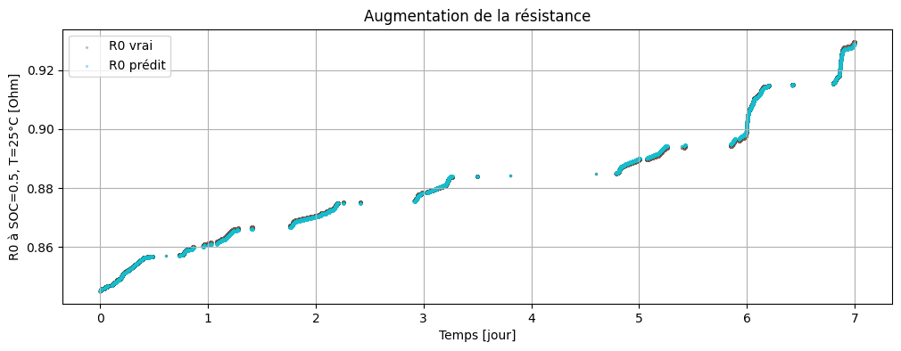

```
R0 vrai final   : 0.9296 Ohm
R0 prédit final : 0.9289 Ohm
```

```python
R0_ref_BOL = float(
    R0_base_np(
        0.5,
        25.0,
    )
)

R0_true = (
    R0_ref_BOL
    * (1.0 + D_R_true)
)

R0_pred = (
    R0_ref_BOL
    * (1.0 + DR_pred)
)

fig = plt.figure(
    figsize=(12, 4)
)

plt.scatter(
    t / 86400,
    R0_true,
    s=SCATTER_SIZE,
    alpha=0.30,
    color=COLOR_DAMAGE,
    label="R0 vrai",
    rasterized=True,
)

plt.scatter(
    t / 86400,
    R0_pred,
    s=SCATTER_SIZE,
    alpha=0.35,
    color=COLOR_PRED,
    label="R0 prédit",
    rasterized=True,
)

plt.xlabel("Temps [jour]")
plt.ylabel("R0 à SOC=0.5, T=25°C [Ohm]")
plt.title("Augmentation de la résistance")
plt.legend()
plt.grid(True)

plt.show()

print(
    "R0 vrai final   :",
    f"{R0_true[-1]:.4f} Ohm"
)

print(
    "R0 prédit final :",
    f"{R0_pred[-1]:.4f} Ohm"
)
```

## Questions

1. La Neural ODE reproduit-elle correctement la tension ?
2. Retrouve-t-elle correctement $C_{\max}$ ?
3. Retrouve-t-elle correctement $D_R$ ?
4. Une excellente erreur sur la tension garantit-elle que les états de santé sont corrects ?
5. Pourquoi le `softplus` est-il utile ?
6. Pourquoi intégrer le vieillissement par rapport à $Q$ plutôt que seulement au temps ?

# Apprendre sur une flotte

On construit maintenant une flotte synthétique de **6 véhicules**, chacun observé pendant 7 jours :

- **Véhicules A, B, C, D** : entraînement ;
- **Véhicules E et F** : test, jamais utilisés pour calculer le gradient.

Tous les véhicules partagent la même loi cachée :

$$ \frac{dD_C^{(v)}}{dQ} = f_{\theta,C} \left( SOC^{(v)}, T^{(v)}, I^{(v)} \right) $$

$$ \frac{dD_R^{(v)}}{dQ} = f_{\theta,R} \left( SOC^{(v)}, T^{(v)}, I^{(v)} \right). $$

Les paramètres $\theta$ du réseau sont partagés entre tous les véhicules d'entraînement.

## Construire les véhicules

Chaque véhicule correspond à un profil d'usage indépendant de 7 jours.

À partir de cette section, les profils sont simplement considérés comme les usages de six véhicules différents.

```python
# Six profils d'usage indépendants de 7 jours.
# Les indices ci-dessous servent uniquement à extraire
# des profils différents du dataset de départ.
VEHICLE_SOURCE_BLOCK = {
    "A": 0,
    "B": 2,
    "C": 4,
    "D": 6,
    "E": 7,
    "F": 10,
}

TRAIN_VEHICLES = [
    "A",
    "B",
    "C",
    "D",
]

TEST_VEHICLES = [
    "E",
    "F",
]


def build_vehicle(
    vehicle_id,
    source_block,
    noise_seed=0,
):
    start = (
        source_block
        * OBS_DURATION_S
    )

    stop = (
        start
        + OBS_DURATION_S
    )

    m = (
        (time_rel_s >= start)
        & (time_rel_s < stop)
    )

    ii = np.where(m)[0]

    if len(ii) < 100:
        raise ValueError(
            f"Profil du véhicule {vehicle_id} trop court."
        )

    tw = (
        time_rel_s[ii]
        - time_rel_s[ii][0]
    )

    Iw = I_all[ii]
    Tw = T_all[ii]
    SOC_ref = SOC_original_all[ii]
    U_RCw = U_RC_all[ii]

    dtw = np.diff(
        tw,
        prepend=tw[0],
    )
    dtw[0] = 0.0

    dtw_eff = np.where(
        dtw <= 60.0,
        dtw,
        0.0,
    )

    dQw = (
        np.abs(Iw)
        * dtw_eff
        / 3600.0
    )

    T_scaled_w = (
        Tw - 25.0
    ) / 20.0

    I_scaled_w = (
        np.abs(Iw)
        / 200.0
    )

    # --------------------------------------------------------
    # MÊMES LOIS AFFINES POUR TOUS LES VÉHICULES
    # --------------------------------------------------------

    stress_Cw = (
        1.0
        + 1.0 * SOC_ref
        + 0.5 * T_scaled_w
        + 0.5 * I_scaled_w
    )

    stress_Rw = (
        1.0
        + 0.5 * SOC_ref
        + 0.5 * T_scaled_w
        + 1.0 * I_scaled_w
    )

    D_C_cyc = np.cumsum(
        kC_true
        * stress_Cw
        * dQw
    )

    D_R_cyc = np.cumsum(
        kR_true
        * stress_Rw
        * dQw
    )

    t_norm = np.clip(
        tw / OBS_DURATION_S,
        0.0,
        1.0,
    )

    D_C_cal = (
        0.005
        * np.sqrt(t_norm)
    )

    D_R_cal = (
        0.010
        * np.sqrt(t_norm)
    )

    D_C = (
        D_C_cal
        + D_C_cyc
    )

    D_R = (
        D_R_cal
        + D_R_cyc
    )

    Cw = (
        C0
        * (1.0 - D_C)
    )

    SOCw = np.zeros_like(
        tw,
        dtype=float,
    )

    SOCw[0] = SOC_ref[0]

    for k in range(
        len(tw) - 1
    ):
        SOCw[k + 1] = np.clip(
            SOCw[k]
            - Iw[k]
            * dtw_eff[k + 1]
            / (
                3600.0
                * Cw[k]
            ),
            0.0,
            1.0,
        )

    R0w = (
        R0_base_np(
            SOCw,
            Tw,
        )
        * (
            1.0
            + D_R
        )
    )

    Uw_clean = (
        OCV_np(SOCw)
        - R0w * Iw
        - np.sum(
            U_RCw,
            axis=1,
        )
    )

    rng = np.random.default_rng(
        noise_seed
    )

    Uw = (
        Uw_clean
        + rng.normal(
            0.0,
            NOISE_STD,
            size=len(Uw_clean),
        )
    )

    return {
        "vehicle_id": vehicle_id,
        "t": tw,
        "dt": dtw_eff,
        "I": Iw,
        "T": Tw,
        "U_RC": U_RCw,
        "U": Uw,
        "U_clean": Uw_clean,
        "SOC": SOCw,
        "C": Cw,
        "D_C": D_C,
        "D_R": D_R,
        "Q_total": float(
            np.sum(dQw)
        ),
    }


fleet = {
    vehicle_id: build_vehicle(
        vehicle_id,
        VEHICLE_SOURCE_BLOCK[
            vehicle_id
        ],
        noise_seed=100
        + ord(vehicle_id),
    )
    for vehicle_id
    in VEHICLE_SOURCE_BLOCK
}

train_fleet = [
    fleet[v]
    for v in TRAIN_VEHICLES
]

test_fleet = [
    fleet[v]
    for v in TEST_VEHICLES
]

for vehicle_id, v in fleet.items():
    role = (
        "train"
        if vehicle_id in TRAIN_VEHICLES
        else "test"
    )

    print(
        f"Véhicule {vehicle_id} "
        f"({role:5s}) | "
        f"N={len(v['t']):6d} | "
        f"Q={v['Q_total']:.1f} Ah | "
        f"Cfin={v['C'][-1]:.2f} Ah | "
        f"D_Rfin={v['D_R'][-1]:.4f}"
    )
```

```
Véhicule A (train) | N=198469 | Q=1560.6 Ah | Cfin=240.00 Ah | D_Rfin=0.1000
Véhicule B (train) | N=259042 | Q=2591.7 Ah | Cfin=233.15 Ah | D_Rfin=0.1700
Véhicule C (train) | N=147888 | Q=2154.2 Ah | Cfin=236.42 Ah | D_Rfin=0.1445
Véhicule D (train) | N=193352 | Q=3062.6 Ah | Cfin=229.22 Ah | D_Rfin=0.2244
Véhicule E (test ) | N=176927 | Q=3004.6 Ah | Cfin=229.10 Ah | D_Rfin=0.2262
Véhicule F (test ) | N=207447 | Q=2248.0 Ah | Cfin=235.11 Ah | D_Rfin=0.1509
```

### À observer avant l'entraînement

La loi cachée est exactement la même pour tous les véhicules.

En revanche, les trajectoires finales de :

$$ C_{\max}(t) $$

et

$$ D_R(t) $$

ne sont pas identiques, car les profils :

$$ SOC(t),\quad T(t),\quad I(t) $$

sont différents.

C'est précisément ce qu'on attend d'une loi d'usage.

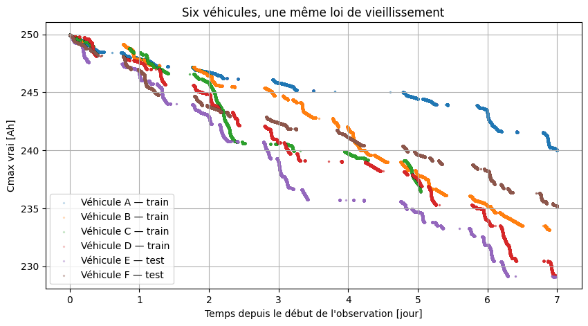

```python
fig = plt.figure(
    figsize=(10, 5)
)

for v in train_fleet:
    plt.scatter(
        v["t"] / 86400,
        v["C"],
        s=SCATTER_SIZE,
        alpha=0.20,
        label=(
            f"Véhicule "
            f"{v['vehicle_id']} — train"
        ),
        rasterized=True,
    )

for v in test_fleet:
    plt.scatter(
        v["t"] / 86400,
        v["C"],
        s=SCATTER_SIZE,
        alpha=0.30,
        label=(
            f"Véhicule "
            f"{v['vehicle_id']} — test"
        ),
        rasterized=True,
    )

plt.xlabel(
    "Temps depuis le début "
    "de l'observation [jour]"
)
plt.ylabel("Cmax vrai [Ah]")

plt.title(
    "Six véhicules, "
    "une même loi de vieillissement"
)

plt.legend()
plt.grid(True)
plt.show()
```

## Simulation d'un véhicule par le réseau partagé

On utilise un seul réseau neuronal pour tous les véhicules.

Le réseau ne reçoit jamais l'identifiant du véhicule.

Ses seules entrées sont :

$$ SOC,\qquad T,\qquad I. $$

La propagation du dommage et du SOC est réalisée avec le même **Euler explicite** que dans le cas mono-véhicule.

```python
def vehicle_to_jax(v):
    return {
        "t": jnp.asarray(v["t"]),
        "dt": jnp.asarray(v["dt"]),
        "I": jnp.asarray(v["I"]),
        "T": jnp.asarray(v["T"]),
        "U_RC": jnp.asarray(v["U_RC"]),
        "U": jnp.asarray(v["U"]),
        "SOC0": jnp.asarray(v["SOC"][0]),
        "C_true": jnp.asarray(v["C"]),
        "DR_true": jnp.asarray(v["D_R"]),
    }

train_fleet_j = [
    vehicle_to_jax(v)
    for v in train_fleet
]

test_fleet_j = [
    vehicle_to_jax(v)
    for v in test_fleet
]
```

```python
def simulate_vehicle(model, vehicle):
    initial_state = jnp.array([
        vehicle["SOC0"],
        0.0,
        0.0,
    ])

    def step(carry, inputs):
        soc, D_C_cyc, D_R_cyc = carry

        tk, dtk, Ik, Tk, urc_k = inputs

        D_C_cal, D_R_cal = calendar_damage(
            tk
        )

        D_C_total = jnp.clip(
            D_C_cal + D_C_cyc,
            0.0,
            0.40,
        )

        D_R_total = jnp.clip(
            D_R_cal + D_R_cyc,
            0.0,
            1.00,
        )

        Cmax = (
            C0_j
            * (1.0 - D_C_total)
        )

        R0 = (
            R0_base_jax(soc, Tk)
            * (1.0 + D_R_total)
        )

        U_pred = (
            OCV_jax(soc)
            - R0 * Ik
            - jnp.sum(urc_k)
        )

        rates = model(
            soc,
            Tk,
            Ik,
        )

        dQk = (
            jnp.abs(Ik)
            * dtk
            / 3600.0
        )

        D_C_cyc_next = (
            D_C_cyc
            + RATE_SCALE_C
            * rates[0]
            * dQk
        )

        D_R_cyc_next = (
            D_R_cyc
            + RATE_SCALE_R
            * rates[1]
            * dQk
        )

        soc_next = (
            soc
            - Ik
            * dtk
            / (3600.0 * Cmax)
        )

        soc_next = jnp.clip(
            soc_next,
            0.0,
            1.0,
        )

        new_carry = jnp.array([
            soc_next,
            D_C_cyc_next,
            D_R_cyc_next,
        ])

        output = jnp.array([
            U_pred,
            soc,
            Cmax,
            R0,
            D_C_total,
            D_R_total,
        ])

        return new_carry, output

    _, outputs = jax.lax.scan(
        step,
        initial_state,
        (
            vehicle["t"],
            vehicle["dt"],
            vehicle["I"],
            vehicle["T"],
            vehicle["U_RC"],
        ),
    )

    return outputs
```

## Loss flotte

La fonction de coût totale est la moyenne des coûts de tous les véhicules d'entraînement :

$$ \boxed{ \mathcal L_{fleet} = \frac{1}{N_v} \sum_v \mathcal L_v } $$

Le point important est que :

$$ \boxed{\theta\text{ est partagé}} $$

alors que chaque véhicule possède sa propre trajectoire d'état.

```python
def vehicle_loss(model, vehicle):
    out = simulate_vehicle(
        model,
        vehicle,
    )

    U_pred = out[:, 0]

    loss_U = jnp.mean(
        (
            (
                U_pred
                - vehicle["U"]
            )
            / 0.5
        )**2
    )

    return loss_U


def fleet_loss(model):
    losses = jnp.stack([
        vehicle_loss(model, v)
        for v in train_fleet_j
    ])

    return jnp.mean(losses)
```

## Entraînement partagé sur les véhicules d'entraînement

On réinitialise volontairement le réseau.

Cette fois, le modèle doit trouver **une seule loi** qui fonctionne simultanément sur les quatre véhicules.

```python
key = jax.random.PRNGKey(42)
fleet_model = AgeingNN(key)
```

```python
fleet_optimizer = optax.chain(
    optax.clip_by_global_norm(1.0),
    optax.adam(1e-3),
)

fleet_opt_state = fleet_optimizer.init(
    eqx.filter(
        fleet_model,
        eqx.is_array,
    )
)

@eqx.filter_jit
def fleet_train_step(
    model,
    opt_state,
):
    loss, grads = eqx.filter_value_and_grad(
        fleet_loss
    )(model)

    updates, opt_state = (
        fleet_optimizer.update(
            grads,
            opt_state,
            eqx.filter(
                model,
                eqx.is_array,
            ),
        )
    )

    model = eqx.apply_updates(
        model,
        updates,
    )

    return (
        model,
        opt_state,
        loss,
    )
```

```python
N_EPOCHS_FLEET = 250

fleet_history = []

for epoch in range(
    N_EPOCHS_FLEET
):
    (
        fleet_model,
        fleet_opt_state,
        loss,
    ) = fleet_train_step(
        fleet_model,
        fleet_opt_state,
    )

    fleet_history.append(
        float(loss)
    )

    if (
        epoch % 10 == 0
        or epoch == N_EPOCHS_FLEET - 1
    ):
        print(
            f"Epoch {epoch:4d} | "
            f"Fleet loss = "
            f"{float(loss):.6f}"
        )
```

```
Epoch    0 | Fleet loss = 0.026056
Epoch   10 | Fleet loss = 0.021234
Epoch   20 | Fleet loss = 0.020184
Epoch   30 | Fleet loss = 0.019554
Epoch   40 | Fleet loss = 0.018943
Epoch   50 | Fleet loss = 0.018571
Epoch   60 | Fleet loss = 0.018242
Epoch   70 | Fleet loss = 0.017952
Epoch   80 | Fleet loss = 0.017653
Epoch   90 | Fleet loss = 0.017348
Epoch  100 | Fleet loss = 0.017093
Epoch  110 | Fleet loss = 0.016782
Epoch  120 | Fleet loss = 0.016496
Epoch  130 | Fleet loss = 0.016210
Epoch  140 | Fleet loss = 0.015853
Epoch  150 | Fleet loss = 0.015525
Epoch  160 | Fleet loss = 0.015224
Epoch  170 | Fleet loss = 0.014921
Epoch  180 | Fleet loss = 0.014616
Epoch  190 | Fleet loss = 0.014313
Epoch  200 | Fleet loss = 0.014010
Epoch  210 | Fleet loss = 0.013723
Epoch  220 | Fleet loss = 0.013425
Epoch  230 | Fleet loss = 0.013146
Epoch  240 | Fleet loss = 0.012864
Epoch  249 | Fleet loss = 0.012629
```

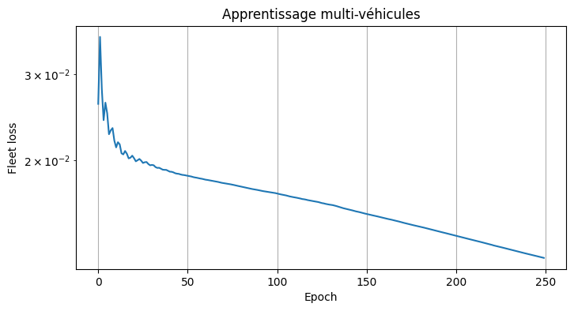

```python
fig = plt.figure(figsize=(8, 4))
plt.semilogy(fleet_history)
plt.xlabel("Epoch")
plt.ylabel("Fleet loss")
plt.title("Apprentissage multi-véhicules")
plt.grid(True)
plt.show()
```

## Sauvegarder la Neural ODE pour le TP suivant

Le réseau multi-véhicule entraîné est celui que l'on veut réutiliser dans le TP suivant.

On sauvegarde uniquement les **poids de la Neural ODE** :

$$ \theta. $$

Les paramètres électriques du modèle équivalent restent connus et fixes.

Dans le TP suivant, on pourra recharger ce réseau, l'évaluer sur de nombreux triplets :

$$ (SOC,T,I) $$

et essayer de retrouver une loi symbolique du type :

$$ a_0+a_1SOC+a_2\widetilde T+a_3\widetilde I. $$

```python
MODEL_WEIGHTS_PATH = (
    "fleet_ageing_neural_ode.eqx"
)

MODEL_METADATA_PATH = (
    "fleet_ageing_neural_ode_metadata.json"
)

# Sauvegarde Equinox des poids
eqx.tree_serialise_leaves(
    MODEL_WEIGHTS_PATH,
    fleet_model,
)

# Métadonnées nécessaires pour le TP suivant
model_metadata = {
    "model": "AgeingNN",
    "inputs": [
        "SOC",
        "T_scaled=(T-25)/20",
        "I_scaled=abs(I)/200",
    ],
    "outputs": [
        "dD_C_cyc/dQ",
        "dD_R_cyc/dQ",
    ],
    "architecture": {
        "in_size": 3,
        "out_size": 2,
        "width_size": 16,
        "depth": 2,
        "activation": "tanh",
        "positive_output": "softplus",
    },
    "rate_scale_C": float(
        RATE_SCALE_C
    ),
    "rate_scale_R": float(
        RATE_SCALE_R
    ),
    "trained_on_vehicles": (
        TRAIN_VEHICLES
    ),
}

with open(
    MODEL_METADATA_PATH,
    "w",
    encoding="utf-8",
) as f:
    json.dump(
        model_metadata,
        f,
        indent=2,
    )

print(
    "Poids sauvegardés :",
    MODEL_WEIGHTS_PATH,
)

print(
    "Métadonnées :",
    MODEL_METADATA_PATH,
)
```

```
Poids sauvegardés : fleet_ageing_neural_ode.eqx
Métadonnées : fleet_ageing_neural_ode_metadata.json
```

Pour le recharger dans le TP suivant :

```
key = jax.random.PRNGKey(0)
template = AgeingNN(key)

model_tp3 = eqx.tree_deserialise_leaves(
    "fleet_ageing_neural_ode.eqx",
    template,
)
```

Le fichier JSON rappelle la normalisation des entrées et les facteurs `RATE_SCALE_C` / `RATE_SCALE_R`.

## Performances sur les véhicules vus

On commence par vérifier que le réseau partagé arrive à représenter simultanément les trajectoires d'entraînement.

```python
for v_np, v_j in zip(
    train_fleet,
    train_fleet_j,
):
    out = np.asarray(
        simulate_vehicle(
            fleet_model,
            v_j,
        )
    )

    U_pred = out[:, 0]
    C_pred = out[:, 2]
    DR_pred = out[:, 5]

    rmse = np.sqrt(
        np.mean(
            (
                U_pred
                - v_np["U"]
            )**2
        )
    )

    print(
        f"Véhicule "
        f"{v_np['vehicle_id']} | "
        f"RMSE U = {rmse:.4f} V | "
        f"Cfin vrai/prédit = "
        f"{v_np['C'][-1]:.2f} / "
        f"{C_pred[-1]:.2f} Ah | "
        f"DRfin vrai/prédit = "
        f"{v_np['D_R'][-1]:.4f} / "
        f"{DR_pred[-1]:.4f}"
    )
```

```
Véhicule A | RMSE U = 0.0994 V | Cfin vrai/prédit = 240.00 / 240.34 Ah | DRfin vrai/prédit = 0.1000 / 0.0975
Véhicule B | RMSE U = 0.1229 V | Cfin vrai/prédit = 233.15 / 233.83 Ah | DRfin vrai/prédit = 0.1700 / 0.1659
Véhicule C | RMSE U = 0.0804 V | Cfin vrai/prédit = 236.42 / 236.28 Ah | DRfin vrai/prédit = 0.1445 / 0.1426
Véhicule D | RMSE U = 0.0917 V | Cfin vrai/prédit = 229.22 / 228.99 Ah | DRfin vrai/prédit = 0.2244 / 0.2220
```

## Généralisation sur deux véhicules jamais vus

Les Véhicules **E et F** n'ont jamais participé au gradient.

On applique exactement le même réseau partagé, sans modifier ses poids.

On compare pour chaque véhicule :

- la tension ;
- la capacité $C_{\max}$ ;
- le dommage résistif $D_R$.

```python
test_results = {}

for v_np, v_j in zip(
    test_fleet,
    test_fleet_j,
):
    out = np.asarray(
        simulate_vehicle(
            fleet_model,
            v_j,
        )
    )

    U_pred = out[:, 0]
    SOC_pred = out[:, 1]
    C_pred = out[:, 2]
    R0_pred = out[:, 3]
    DR_pred = out[:, 5]

    rmse = np.sqrt(
        np.mean(
            (
                U_pred
                - v_np["U"]
            )**2
        )
    )

    test_results[
        v_np["vehicle_id"]
    ] = {
        "U": U_pred,
        "SOC": SOC_pred,
        "C": C_pred,
        "R0": R0_pred,
        "DR": DR_pred,
        "rmse_U": rmse,
    }

    print(
        f"Test Véhicule "
        f"{v_np['vehicle_id']} | "
        f"RMSE U={rmse:.4f} V | "
        f"Cfin vrai/prédit="
        f"{v_np['C'][-1]:.2f} / "
        f"{C_pred[-1]:.2f} Ah | "
        f"D_R fin vrai/prédit="
        f"{v_np['D_R'][-1]:.4f} / "
        f"{DR_pred[-1]:.4f}"
    )
```

```
Test Véhicule E | RMSE U=0.1898 V | Cfin vrai/prédit=229.10 / 229.11 Ah | D_R fin vrai/prédit=0.2262 / 0.2212
Test Véhicule F | RMSE U=0.1325 V | Cfin vrai/prédit=235.11 / 235.66 Ah | D_R fin vrai/prédit=0.1509 / 0.1471
```

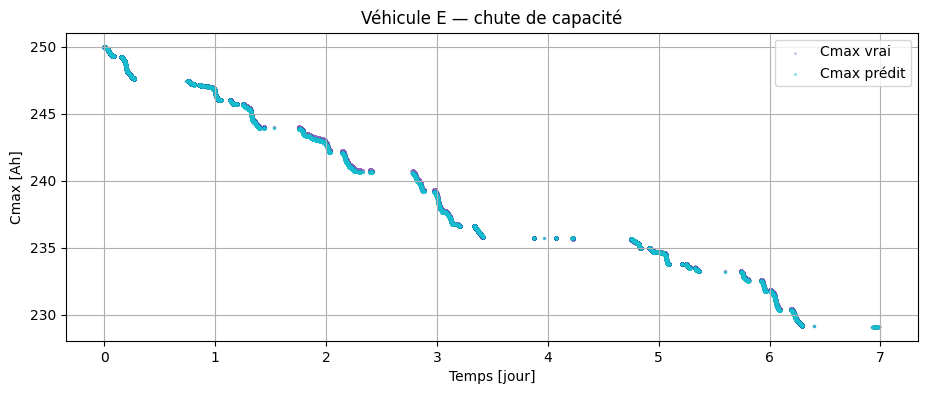

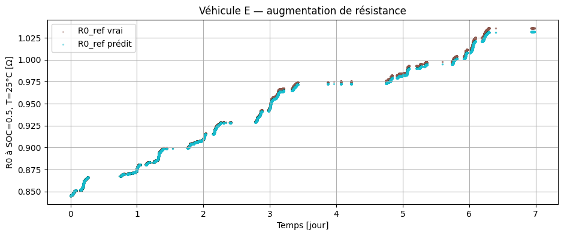

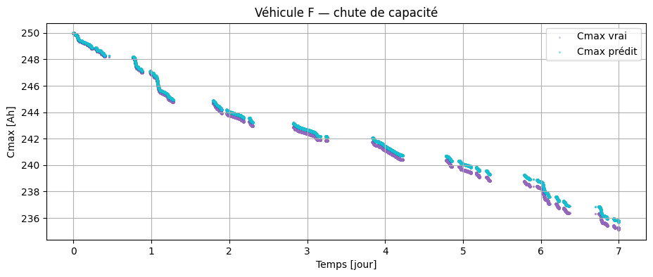

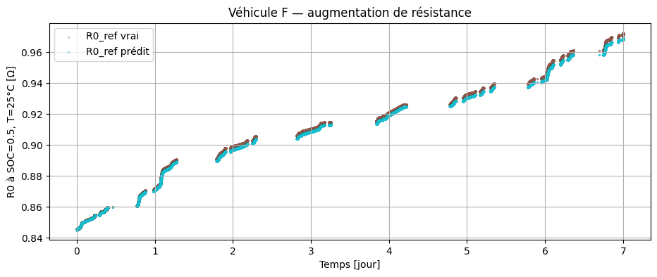

```python
R0_REF_BOL = float(
    R0_base_np(
        0.5,
        25.0,
    )
)

for v in test_fleet:
    vehicle_id = (
        v["vehicle_id"]
    )

    pred = test_results[
        vehicle_id
    ]

    # --------------------------------------------------------
    # CAPACITÉ
    # --------------------------------------------------------

    fig = plt.figure(
        figsize=(11, 4)
    )

    plt.scatter(
        v["t"] / 86400,
        v["C"],
        s=SCATTER_SIZE,
        alpha=0.25,
        color=COLOR_C,
        label="Cmax vrai",
        rasterized=True,
    )

    plt.scatter(
        v["t"] / 86400,
        pred["C"],
        s=SCATTER_SIZE,
        alpha=0.35,
        color=COLOR_PRED,
        label="Cmax prédit",
        rasterized=True,
    )

    plt.xlabel("Temps [jour]")
    plt.ylabel("Cmax [Ah]")
    plt.title(
        f"Véhicule {vehicle_id} — "
        "chute de capacité"
    )
    plt.legend()
    plt.grid(True)
    plt.show()

    # --------------------------------------------------------
    # RÉSISTANCE À CONDITIONS DE RÉFÉRENCE
    # --------------------------------------------------------

    R0_ref_true = (
        R0_REF_BOL
        * (
            1.0
            + v["D_R"]
        )
    )

    R0_ref_pred = (
        R0_REF_BOL
        * (
            1.0
            + pred["DR"]
        )
    )

    fig = plt.figure(
        figsize=(11, 4)
    )

    plt.scatter(
        v["t"] / 86400,
        R0_ref_true,
        s=SCATTER_SIZE,
        alpha=0.25,
        color=COLOR_DAMAGE,
        label="R0_ref vrai",
        rasterized=True,
    )

    plt.scatter(
        v["t"] / 86400,
        R0_ref_pred,
        s=SCATTER_SIZE,
        alpha=0.35,
        color=COLOR_PRED,
        label="R0_ref prédit",
        rasterized=True,
    )

    plt.xlabel("Temps [jour]")
    plt.ylabel("R0 à SOC=0.5, T=25°C [Ω]")
    plt.title(
        f"Véhicule {vehicle_id} — "
        "augmentation de résistance"
    )
    plt.legend()
    plt.grid(True)
    plt.show()
```

## Comparer mono-véhicule et flotte

Le modèle mono-véhicule répond à :

$$ \boxed{ \text{Puis-je expliquer cette trajectoire ?} } $$

Le modèle flotte répond à une question beaucoup plus intéressante :

$$ \boxed{ \text{Puis-je apprendre une loi commune capable de générer de nouvelles trajectoires ?} } $$

C'est une différence conceptuelle importante.

Dans le premier cas, le réseau peut exploiter des corrélations propres à un véhicule.

Dans le second, plusieurs trajectoires différentes contraignent simultanément la fonction :

$$ f_\theta. $$

La diversité des scénarios améliore donc potentiellement l'identification de la loi d'usage.

## Questions

1. Pourquoi plusieurs véhicules peuvent-ils aider à apprendre une loi de vieillissement plutôt qu'une trajectoire ?
2. Quels paramètres sont partagés entre les véhicules ?
3. Quels états restent propres à chaque véhicule ?
4. Pourquoi l'identifiant du véhicule n'est-il pas fourni au réseau ?
5. Le modèle généralise-t-il correctement au Véhicule F ?
6. Que se passerait-il si tous les véhicules avaient exactement le même profil d'usage ?
7. Pourquoi la loi affine choisie ici sera-t-elle pratique dans un TP ultérieur de régression symbolique ?

# Une flotte avec mémoire

On construit maintenant une seconde version de la flotte.

La loi instantanée de base reste volontairement très simple :

$$ g_C(SOC,T,I) = 1+SOC+0.5\widetilde T+0.5\widetilde I $$

$$ g_R(SOC,T,I) = 1+0.5SOC+0.5\widetilde T+\widetilde I. $$

Mais chaque véhicule possède maintenant un **historique caché différent**, résumé par un état mémoire $h(t)$.

L'effet mémoire est volontairement fort pour que le Neural ODE sans mémoire ait réellement des difficultés sur les deux véhicules de test.

## Un état mémoire lent

On définit un stress historique simple :

$$ s(t) = 0.5\,SOC(t) + 0.5\,T_h(t) $$

avec

$$ T_h = \mathrm{clip} \left( \frac{T-10}{40}, 0, 1 \right). $$

La mémoire évolue lentement :

$$ \boxed{ \frac{dh}{dt} = \frac{s(t)-h(t)}{\tau_h} } $$

avec

$$ \tau_h = 14~jours. $$

Comme notre observation ne dure que 7 jours, le véhicule conserve une part importante de son **historique antérieur**.

### Une histoire différente pour chaque véhicule

On suppose que les six véhicules ont vécu des usages différents **avant le début de l'observation**.

On impose donc des mémoires initiales différentes :

$$ h_A(0)=0.20,\quad h_B(0)=0.40,\quad h_C(0)=0.60, $$

$$ h_D(0)=0.80,\quad h_E(0)=0.95,\quad h_F(0)=0.05. $$

Les Véhicules E et F sont volontairement plus extrêmes.

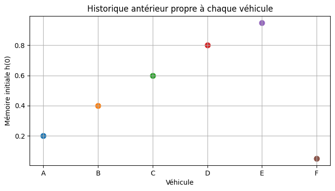

```python
# ============================================================
# MÉMOIRE SYNTHÉTIQUE FORCÉE
# ============================================================

TAU_MEMORY = (
    14.0
    * 24.0
    * 3600.0
)

# Effet volontairement fort pour le TP
MEMORY_BETA_C = 1.6
MEMORY_BETA_R = 1.8

H0_MEMORY = {
    "A": 0.20,
    "B": 0.40,
    "C": 0.60,
    "D": 0.80,
    "E": 0.95,
    "F": 0.05,
}


def instantaneous_memory_stress(
    soc,
    temp,
):
    """
    Résumé simple des conditions actuelles.
    Valeur approximativement comprise entre 0 et 1.
    """
    temp_history = np.clip(
        (temp - 10.0) / 40.0,
        0.0,
        1.0,
    )

    return (
        0.5 * soc
        + 0.5 * temp_history
    )


def memory_factor(
    h,
    beta,
):
    """
    Facteur centré autour de h=0.5.

    h faible  -> vieillissement plus lent
    h élevé   -> vieillissement plus rapide
    """
    return (
        1.0
        + beta
        * (h - 0.5)
    )


# Visualisation de l'historique initial imposé
fig = plt.figure(
    figsize=(8, 4)
)

for vehicle_id, h0 in H0_MEMORY.items():
    plt.scatter(
        vehicle_id,
        h0,
        s=60,
    )

plt.xlabel("Véhicule")
plt.ylabel("Mémoire initiale h(0)")
plt.title(
    "Historique antérieur propre à chaque véhicule"
)
plt.grid(True)
plt.show()
```

## Loi réelle avec mémoire

La loi instantanée est :

$$ g_C(SOC,T,I) = 1+SOC+0.5\,\widetilde T+0.5\,\widetilde I $$

$$ g_R(SOC,T,I) = 1+0.5\,SOC+0.5\,\widetilde T+\widetilde I. $$

On ajoute un facteur historique :

$$ \boxed{ \frac{dD_C}{dQ} = k_C\, g_C(SOC,T,I) \left[ 1+\beta_C(h-0.5) \right] } $$

$$ \boxed{ \frac{dD_R}{dQ} = k_R\, g_R(SOC,T,I) \left[ 1+\beta_R(h-0.5) \right]. } $$

Deux véhicules placés au même $SOC$, à la même température et au même courant peuvent donc vieillir différemment si :

$$ h^{(1)}\neq h^{(2)}. $$

```python
def build_vehicle_with_memory(
    vehicle_id,
    source_block,
    noise_seed=0,
):
    start = (
        source_block
        * OBS_DURATION_S
    )

    stop = (
        start
        + OBS_DURATION_S
    )

    m = (
        (time_rel_s >= start)
        & (time_rel_s < stop)
    )

    ii = np.where(m)[0]

    if len(ii) < 100:
        raise ValueError(
            f"Profil du véhicule {vehicle_id} trop court."
        )

    tw = (
        time_rel_s[ii]
        - time_rel_s[ii][0]
    )

    Iw = I_all[ii]
    Tw = T_all[ii]
    SOC_ref = SOC_original_all[ii]
    U_RCw = U_RC_all[ii]

    dtw = np.diff(
        tw,
        prepend=tw[0],
    )
    dtw[0] = 0.0

    dtw_eff = np.where(
        dtw <= 60.0,
        dtw,
        0.0,
    )

    dQw = (
        np.abs(Iw)
        * dtw_eff
        / 3600.0
    )

    # --------------------------------------------------------
    # MÉMOIRE
    # --------------------------------------------------------

    h = np.zeros_like(
        tw,
        dtype=float,
    )

    h[0] = H0_MEMORY[
        vehicle_id
    ]

    mem_stress = (
        instantaneous_memory_stress(
            SOC_ref,
            Tw,
        )
    )

    for k in range(
        len(tw) - 1
    ):
        alpha = (
            1.0
            - np.exp(
                -dtw_eff[k + 1]
                / TAU_MEMORY
            )
        )

        h[k + 1] = (
            h[k]
            + alpha
            * (
                mem_stress[k]
                - h[k]
            )
        )

    # --------------------------------------------------------
    # LOI AFFINE INSTANTANÉE
    # --------------------------------------------------------

    T_scaled_w = (
        Tw - 25.0
    ) / 20.0

    I_scaled_w = (
        np.abs(Iw)
        / 200.0
    )

    stress_C = (
        1.0
        + 1.0 * SOC_ref
        + 0.5 * T_scaled_w
        + 0.5 * I_scaled_w
    )

    stress_R = (
        1.0
        + 0.5 * SOC_ref
        + 0.5 * T_scaled_w
        + 1.0 * I_scaled_w
    )

    # --------------------------------------------------------
    # EFFET HISTORIQUE FORT
    # --------------------------------------------------------

    factor_C = memory_factor(
        h,
        MEMORY_BETA_C,
    )

    factor_R = memory_factor(
        h,
        MEMORY_BETA_R,
    )

    rate_C = (
        kC_true
        * stress_C
        * factor_C
    )

    rate_R = (
        kR_true
        * stress_R
        * factor_R
    )

    D_C_cyc = np.cumsum(
        rate_C * dQw
    )

    D_R_cyc = np.cumsum(
        rate_R * dQw
    )

    t_norm = np.clip(
        tw / OBS_DURATION_S,
        0.0,
        1.0,
    )

    D_C_cal = (
        0.005
        * np.sqrt(t_norm)
    )

    D_R_cal = (
        0.010
        * np.sqrt(t_norm)
    )

    D_C = (
        D_C_cal
        + D_C_cyc
    )

    D_R = (
        D_R_cal
        + D_R_cyc
    )

    Cw = (
        C0
        * (1.0 - D_C)
    )

    SOCw = np.zeros_like(
        tw,
        dtype=float,
    )

    SOCw[0] = SOC_ref[0]

    for k in range(
        len(tw) - 1
    ):
        SOCw[k + 1] = np.clip(
            SOCw[k]
            - Iw[k]
            * dtw_eff[k + 1]
            / (
                3600.0
                * Cw[k]
            ),
            0.0,
            1.0,
        )

    R0w = (
        R0_base_np(
            SOCw,
            Tw,
        )
        * (
            1.0
            + D_R
        )
    )

    Uw_clean = (
        OCV_np(SOCw)
        - R0w * Iw
        - np.sum(
            U_RCw,
            axis=1,
        )
    )

    rng = np.random.default_rng(
        noise_seed
    )

    Uw = (
        Uw_clean
        + rng.normal(
            0.0,
            NOISE_STD,
            size=len(Uw_clean),
        )
    )

    return {
        "vehicle_id": vehicle_id,
        "t": tw,
        "dt": dtw_eff,
        "I": Iw,
        "T": Tw,
        "U_RC": U_RCw,
        "U": Uw,
        "SOC": SOCw,
        "C": Cw,
        "D_C": D_C,
        "D_R": D_R,
        "h": h,
        "h0": float(h[0]),
        "rate_C_true": rate_C,
        "rate_R_true": rate_R,
    }


memory_fleet = {
    vehicle_id: build_vehicle_with_memory(
        vehicle_id,
        VEHICLE_SOURCE_BLOCK[
            vehicle_id
        ],
        noise_seed=500
        + ord(vehicle_id),
    )
    for vehicle_id
    in VEHICLE_SOURCE_BLOCK
}

memory_train_fleet = [
    memory_fleet[v]
    for v in TRAIN_VEHICLES
]

memory_test_fleet = [
    memory_fleet[v]
    for v in TEST_VEHICLES
]


for vehicle_id, v in memory_fleet.items():
    role = (
        "train"
        if vehicle_id in TRAIN_VEHICLES
        else "test"
    )

    print(
        f"Véhicule {vehicle_id} "
        f"({role:10s}) | "
        f"h0={v['h0']:.2f} | "
        f"h moyen={np.mean(v['h']):.3f} | "
        f"Cfin={v['C'][-1]:.2f} Ah | "
        f"D_Rfin={v['D_R'][-1]:.4f}"
    )
```

```
Véhicule A (train     ) | h0=0.20 | h moyen=0.228 | Cfin=243.75 Ah | D_Rfin=0.0568
Véhicule B (train     ) | h0=0.40 | h moyen=0.424 | Cfin=235.08 Ah | D_Rfin=0.1477
Véhicule C (train     ) | h0=0.60 | h moyen=0.600 | Cfin=234.43 Ah | D_Rfin=0.1688
Véhicule D (train     ) | h0=0.80 | h moyen=0.786 | Cfin=220.30 Ah | D_Rfin=0.3345
Véhicule E (test      ) | h0=0.95 | h moyen=0.929 | Cfin=215.65 Ah | D_Rfin=0.3927
Véhicule F (test      ) | h0=0.05 | h moyen=0.099 | Cfin=243.89 Ah | D_Rfin=0.0489
```

## Visualiser la mémoire propre à chaque véhicule

On observe maintenant la mémoire $h(t)$ de chaque véhicule.

Comme $\tau_h$ est long devant la durée d'observation, les différences initiales restent visibles pendant plusieurs jours.

C'est cette information historique qui manque au modèle sans mémoire.

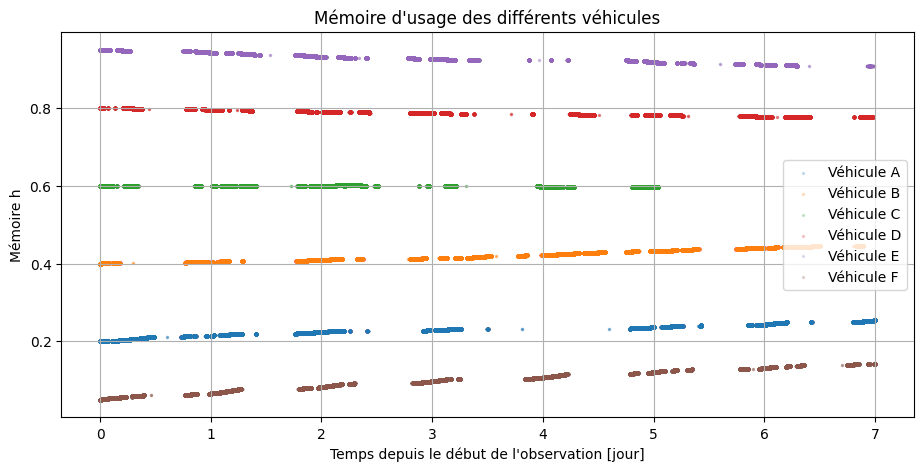

```python
fig = plt.figure(
    figsize=(11, 5)
)

for vehicle_id, v in memory_fleet.items():
    plt.scatter(
        v["t"] / 86400,
        v["h"],
        s=SCATTER_SIZE,
        alpha=0.20,
        label=f"Véhicule {vehicle_id}",
        rasterized=True,
    )

plt.xlabel(
    "Temps depuis le début "
    "de l'observation [jour]"
)
plt.ylabel("Mémoire h")

plt.title(
    "Mémoire d'usage des différents véhicules"
)

plt.legend()
plt.grid(True)
plt.show()
```

On compare aussi des instants où les véhicules se trouvent dans une zone similaire de l'espace instantané :

$$ SOC\approx0.70, \qquad T\approx30^\circ C, \qquad |I|\approx100~A. $$

Si le vieillissement dépendait uniquement de $SOC$, $T$ et $I$, les vitesses $dD_C/dQ$ devraient être proches.

Avec la mémoire, elles restent différentes.

Pour rendre le graphique lisible, on affiche un point moyen par véhicule.

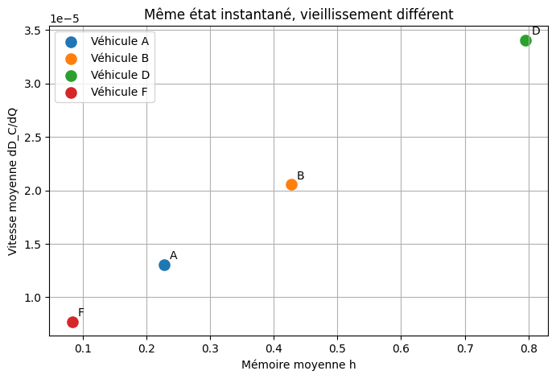

```python
TARGET_SOC = 0.70
TARGET_T = 30.0
TARGET_I = 100.0

SOC_TOL = 0.03
T_TOL = 2.0
I_TOL = 20.0

fig = plt.figure(
    figsize=(8, 5)
)

for vehicle_id, v in memory_fleet.items():
    mask_local = (
        (
            np.abs(
                v["SOC"]
                - TARGET_SOC
            )
            < SOC_TOL
        )
        & (
            np.abs(
                v["T"]
                - TARGET_T
            )
            < T_TOL
        )
        & (
            np.abs(
                np.abs(v["I"])
                - TARGET_I
            )
            < I_TOL
        )
    )

    if np.sum(mask_local) == 0:
        continue

    h_mean = np.mean(
        v["h"][mask_local]
    )

    rate_mean = np.mean(
        v["rate_C_true"][
            mask_local
        ]
    )

    plt.scatter(
        h_mean,
        rate_mean,
        s=90,
        label=f"Véhicule {vehicle_id}",
    )

    plt.annotate(
        vehicle_id,
        (
            h_mean,
            rate_mean,
        ),
        xytext=(5, 5),
        textcoords="offset points",
    )

plt.xlabel("Mémoire moyenne h")
plt.ylabel(
    "Vitesse moyenne dD_C/dQ"
)

plt.title(
    "Même état instantané, "
    "vieillissement différent"
)

plt.legend()
plt.grid(True)
plt.show()
```

## Entraîner volontairement un modèle sans mémoire

On entraîne le Neural ODE :

$$ \boxed{ \frac{dD}{dQ} = f_\theta(SOC,T,I) } $$

alors que les données ont été générées avec :

$$ \boxed{ \frac{dD}{dQ} = f(SOC,T,I,h). } $$

Le modèle est volontairement incomplet.

Il peut apprendre une loi moyenne sur les Véhicules A à D, mais les Véhicules E et F possèdent des mémoires initiales volontairement atypiques.

Ils servent tous les deux de **véhicules de test**.

```python
def memory_vehicle_to_jax(v):
    return {
        "t": jnp.asarray(v["t"]),
        "dt": jnp.asarray(v["dt"]),
        "I": jnp.asarray(v["I"]),
        "T": jnp.asarray(v["T"]),
        "U_RC": jnp.asarray(v["U_RC"]),
        "U": jnp.asarray(v["U"]),
        "SOC0": jnp.asarray(v["SOC"][0]),
        "C_true": jnp.asarray(v["C"]),
        "DR_true": jnp.asarray(v["D_R"]),
        "h": jnp.asarray(v["h"]),
    }

memory_train_fleet_j = [
    memory_vehicle_to_jax(v)
    for v in memory_train_fleet
]

memory_test_fleet_j = [
    memory_vehicle_to_jax(v)
    for v in memory_test_fleet
]
```

On réutilise volontairement `simulate_vehicle(...)`, qui **n'a pas accès à $h$**.

La loss est exactement la même que dans l'expérience flotte précédente.

```python
def no_memory_vehicle_loss(
    model,
    vehicle,
):
    out = simulate_vehicle(
        model,
        vehicle,
    )

    U_pred = out[:, 0]

    loss_U = jnp.mean(
        (
            (
                U_pred
                - vehicle["U"]
            )
            / 0.5
        )**2
    )

    return loss_U


def no_memory_fleet_loss(
    model,
):
    return jnp.mean(
        jnp.stack([
            no_memory_vehicle_loss(
                model,
                v,
            )
            for v
            in memory_train_fleet_j
        ])
    )
```

```python
key = jax.random.PRNGKey(123)

no_memory_model = AgeingNN(
    key
)
```

```python
optimizer_nm = optax.chain(
    optax.clip_by_global_norm(1.0),
    optax.adam(1e-3),
)

opt_state_nm = optimizer_nm.init(
    eqx.filter(
        no_memory_model,
        eqx.is_array,
    )
)

@eqx.filter_jit
def train_step_no_memory(
    model,
    opt_state,
):
    loss, grads = (
        eqx.filter_value_and_grad(
            no_memory_fleet_loss
        )(model)
    )

    updates, opt_state = (
        optimizer_nm.update(
            grads,
            opt_state,
            eqx.filter(
                model,
                eqx.is_array,
            ),
        )
    )

    model = eqx.apply_updates(
        model,
        updates,
    )

    return (
        model,
        opt_state,
        loss,
    )
```

```python
N_EPOCHS_MEMORY_TEST = 300

history_nm = []

for epoch in range(
    N_EPOCHS_MEMORY_TEST
):
    (
        no_memory_model,
        opt_state_nm,
        loss,
    ) = train_step_no_memory(
        no_memory_model,
        opt_state_nm,
    )

    history_nm.append(
        float(loss)
    )

    if (
        epoch % 10 == 0
        or epoch
        == N_EPOCHS_MEMORY_TEST - 1
    ):
        print(
            f"Epoch {epoch:4d} | "
            f"Loss sans mémoire = "
            f"{float(loss):.6f}"
        )
```

```
Epoch    0 | Loss sans mémoire = 0.716664
Epoch   10 | Loss sans mémoire = 0.618919
Epoch   20 | Loss sans mémoire = 0.608723
Epoch   30 | Loss sans mémoire = 0.597109
```

[output not shown]

## Le modèle sans mémoire fonctionne... mais moins bien

Le résultat attendu n'est pas nécessairement un échec catastrophique.

Le réseau peut apprendre une **loi moyenne** qui fonctionne raisonnablement sur les véhicules d'entraînement.

En revanche, les erreurs deviennent plus dépendantes du véhicule, notamment lorsque sa mémoire initiale est atypique.

```python
def evaluate_no_memory(
    model,
    vehicle_np,
    vehicle_j,
    role,
):
    out = np.asarray(
        simulate_vehicle(
            model,
            vehicle_j,
        )
    )

    U_pred = out[:, 0]
    C_pred = out[:, 2]
    DR_pred = out[:, 5]

    rmse_U = np.sqrt(
        np.mean(
            (
                U_pred
                - vehicle_np["U"]
            )**2
        )
    )

    err_C_final = (
        C_pred[-1]
        - vehicle_np["C"][-1]
    )

    err_DR_final = (
        DR_pred[-1]
        - vehicle_np["D_R"][-1]
    )

    print(
        f"{role:6s} | "
        f"Véhicule "
        f"{vehicle_np['vehicle_id']} | "
        f"RMSE U={rmse_U:.4f} V | "
        f"Erreur Cfin="
        f"{err_C_final:+.2f} Ah | "
        f"Erreur DRfin="
        f"{err_DR_final:+.4f}"
    )

    return (
        U_pred,
        C_pred,
        DR_pred,
    )


for v_np, v_j in zip(
    memory_train_fleet,
    memory_train_fleet_j,
):
    evaluate_no_memory(
        no_memory_model,
        v_np,
        v_j,
        "Train",
    )

no_memory_test_results = {}

for v_np, v_j in zip(
    memory_test_fleet,
    memory_test_fleet_j,
):
    (
        U_pred,
        C_pred,
        DR_pred,
    ) = evaluate_no_memory(
        no_memory_model,
        v_np,
        v_j,
        "Test",
    )

    no_memory_test_results[
        v_np["vehicle_id"]
    ] = {
        "U": U_pred,
        "C": C_pred,
        "DR": DR_pred,
    }
```

```
Train  | Véhicule A | RMSE U=0.4784 V | Erreur Cfin=-1.12 Ah | Erreur DRfin=+0.0223
Train  | Véhicule B | RMSE U=0.2784 V | Erreur Cfin=+1.59 Ah | Erreur DRfin=-0.0030
Train  | Véhicule C | RMSE U=0.4397 V | Erreur Cfin=+1.39 Ah | Erreur DRfin=-0.0030
Train  | Véhicule D | RMSE U=0.3001 V | Erreur Cfin=+1.99 Ah | Erreur DRfin=+0.0071
Test   | Véhicule E | RMSE U=1.6478 V | Erreur Cfin=+5.90 Ah | Erreur DRfin=-0.0403
Test   | Véhicule F | RMSE U=2.4768 V | Erreur Cfin=-5.88 Ah | Erreur DRfin=+0.0806
```

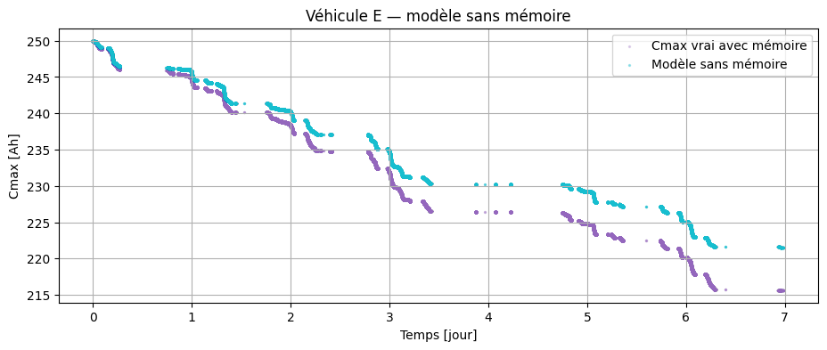

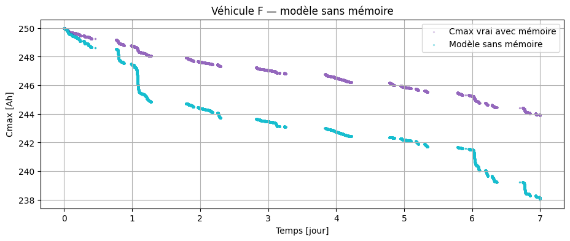

```python
for v in memory_test_fleet:
    vehicle_id = (
        v["vehicle_id"]
    )

    pred = (
        no_memory_test_results[
            vehicle_id
        ]
    )

    fig = plt.figure(
        figsize=(11, 4)
    )

    plt.scatter(
        v["t"] / 86400,
        v["C"],
        s=SCATTER_SIZE,
        alpha=0.25,
        color=COLOR_C,
        label="Cmax vrai avec mémoire",
        rasterized=True,
    )

    plt.scatter(
        v["t"] / 86400,
        pred["C"],
        s=SCATTER_SIZE,
        alpha=0.35,
        color=COLOR_PRED,
        label="Modèle sans mémoire",
        rasterized=True,
    )

    plt.xlabel("Temps [jour]")
    plt.ylabel("Cmax [Ah]")

    plt.title(
        f"Véhicule {vehicle_id} — "
        "modèle sans mémoire"
    )

    plt.legend()
    plt.grid(True)
    plt.show()
```

## Donner explicitement la mémoire au réseau

On entraîne maintenant un second réseau qui reçoit :

$$ SOC,\quad T,\quad I,\quad h. $$

Il apprend :

$$ \boxed{ \frac{dD}{dQ} = f_\theta(SOC,T,I,h). } $$

Ici, $h$ est encore fourni explicitement.

```python
class AgeingNNWithMemory(eqx.Module):
    mlp: eqx.nn.MLP

    def __init__(self, key):
        self.mlp = eqx.nn.MLP(
            in_size=4,
            out_size=2,
            width_size=16,
            depth=2,
            activation=jax.nn.tanh,
            key=key,
        )

    def __call__(
        self,
        soc,
        temp,
        current,
        h,
    ):
        x = jnp.array([
            soc,
            (temp - 25.0) / 20.0,
            jnp.abs(current) / 200.0,
            h,
        ])

        raw = self.mlp(x)

        return jax.nn.softplus(
            raw
        )
```

```python
def simulate_vehicle_with_memory(
    model,
    vehicle,
):
    initial_state = jnp.array([
        vehicle["SOC0"],
        0.0,
        0.0,
    ])

    def step(carry, inputs):
        (
            soc,
            D_C_cyc,
            D_R_cyc,
        ) = carry

        (
            tk,
            dtk,
            Ik,
            Tk,
            urc_k,
            hk,
        ) = inputs

        (
            D_C_cal,
            D_R_cal,
        ) = calendar_damage(
            tk
        )

        D_C_total = jnp.clip(
            D_C_cal
            + D_C_cyc,
            0.0,
            0.40,
        )

        D_R_total = jnp.clip(
            D_R_cal
            + D_R_cyc,
            0.0,
            1.00,
        )

        Cmax = (
            C0_j
            * (
                1.0
                - D_C_total
            )
        )

        R0 = (
            R0_base_jax(
                soc,
                Tk,
            )
            * (
                1.0
                + D_R_total
            )
        )

        U_pred = (
            OCV_jax(soc)
            - R0 * Ik
            - jnp.sum(urc_k)
        )

        rates = model(
            soc,
            Tk,
            Ik,
            hk,
        )

        dQk = (
            jnp.abs(Ik)
            * dtk
            / 3600.0
        )

        D_C_cyc_next = (
            D_C_cyc
            + RATE_SCALE_C
            * rates[0]
            * dQk
        )

        D_R_cyc_next = (
            D_R_cyc
            + RATE_SCALE_R
            * rates[1]
            * dQk
        )

        soc_next = (
            soc
            - Ik
            * dtk
            / (
                3600.0
                * Cmax
            )
        )

        soc_next = jnp.clip(
            soc_next,
            0.0,
            1.0,
        )

        return (
            jnp.array([
                soc_next,
                D_C_cyc_next,
                D_R_cyc_next,
            ]),
            jnp.array([
                U_pred,
                soc,
                Cmax,
                R0,
                D_C_total,
                D_R_total,
            ]),
        )

    _, outputs = jax.lax.scan(
        step,
        initial_state,
        (
            vehicle["t"],
            vehicle["dt"],
            vehicle["I"],
            vehicle["T"],
            vehicle["U_RC"],
            vehicle["h"],
        ),
    )

    return outputs
```

```python
def memory_vehicle_loss(
    model,
    vehicle,
):
    out = simulate_vehicle_with_memory(
        model,
        vehicle,
    )

    U_pred = out[:, 0]

    loss_U = jnp.mean(
        (
            (
                U_pred
                - vehicle["U"]
            )
            / 0.5
        )**2
    )

    return loss_U


def memory_fleet_loss(
    model,
):
    return jnp.mean(
        jnp.stack([
            memory_vehicle_loss(
                model,
                v,
            )
            for v
            in memory_train_fleet_j
        ])
    )
```

```python
key = jax.random.PRNGKey(321)

memory_model = AgeingNNWithMemory(
    key
)
```

```python
optimizer_mem = optax.chain(
    optax.clip_by_global_norm(1.0),
    optax.adam(1e-2),
)

opt_state_mem = optimizer_mem.init(
    eqx.filter(
        memory_model,
        eqx.is_array,
    )
)

@eqx.filter_jit
def train_step_memory(
    model,
    opt_state,
):
    loss, grads = (
        eqx.filter_value_and_grad(
            memory_fleet_loss
        )(model)
    )

    updates, opt_state = (
        optimizer_mem.update(
            grads,
            opt_state,
            eqx.filter(
                model,
                eqx.is_array,
            ),
        )
    )

    model = eqx.apply_updates(
        model,
        updates,
    )

    return (
        model,
        opt_state,
        loss,
    )
```

```python
history_mem = []
N_EPOCHS_MEMORY_TEST = 300
for epoch in range(
    N_EPOCHS_MEMORY_TEST
):
    (
        memory_model,
        opt_state_mem,
        loss,
    ) = train_step_memory(
        memory_model,
        opt_state_mem,
    )

    history_mem.append(
        float(loss)
    )

    if (
        epoch % 10 == 0
        or epoch
        == N_EPOCHS_MEMORY_TEST - 1
    ):
        print(
            f"Epoch {epoch:4d} | "
            f"Loss avec mémoire = "
            f"{float(loss):.6f}"
        )
```

```
Epoch    0 | Loss avec mémoire = 87.678902
Epoch   10 | Loss avec mémoire = 18.478611
Epoch   20 | Loss avec mémoire = 12.018182
Epoch   30 | Loss avec mémoire = 5.054776
Epoch   40 | Loss avec mémoire = 0.113078
Epoch   50 | Loss avec mémoire = 0.471098
Epoch   60 | Loss avec mémoire = 0.174356
Epoch   70 | Loss avec mémoire = 0.160317
```

[output not shown]